# Modeling NYC Citibike

Christina Saparinatou

Sithipath Yooprong

Zain Abdelrazeq

# Abstract

In a bike-sharing system, the prediction of the availability of the bikes is crucial for providing efficient service. In this report, we will simulate the number of available bikes every 10-minutes of the morning and evening hours using Makov Chains. By doing that, we are estimating the steady-state of the number of available bikes in a station.

We use CitiBike data collected from NYC to build a Markov Chain model for each bike station.

The analysis and results presented in the report can provide insights on how to better manage the bike-sharing system in popular areas around NYC to provide an optimal customer-centric service.

# Read Data

First, we imported all libraries needed for the project.

```python
import numpy as np
import pandas as pd
from datetime import datetime
import os, sys, math
from statistics import mean
import matplotlib.pyplot as plt
import warnings
warnings.filterwarnings("ignore")
pd.set_option('display.max_rows', None)
```

We then read the CitiBike data for the month of July 2022, which was downloaded from the dataset “202207-citbike-tripdata.csv.zip” from the link https://s3.amazonaws.com/tripdata/index.html.

```python
df = pd.read_csv('202207-citbike-tripdata.csv')
```

```python
df.head()
```

|  | ride_id | rideable_type | started_at | ended_at | start_station_name | start_station_id | end_station_name | end_station_id | start_lat | start_lng | end_lat | end_lng | member_casual |
| --- | --- | --- | --- | --- | --- | --- | --- | --- | --- | --- | --- | --- | --- |
| 0 | C09E4093905089BD | classic_bike | 2022-07-23 11:34:57 | 2022-07-23 11:45:08 | Melrose St & Broadway | 4801.04 | Myrtle Ave & Grove St | 4816.05 | 40.697481 | -73.935877 | 40.699050 | -73.915160 | member |
| 1 | 374630DB5822C392 | electric_bike | 2022-07-29 18:19:08 | 2022-07-29 18:26:50 | E 68 St & 3 Ave | 6896.16 | E 85 St & York Ave | 7146.04 | 40.767128 | -73.962246 | 40.775369 | -73.948034 | member |
| 2 | 4F73CA25880A1215 | electric_bike | 2022-07-16 16:30:58 | 2022-07-16 17:39:18 | W 37 St & 10 Ave | 6611.02 | Knickerbocker Ave & Cooper St | 4582.05 | 40.756604 | -73.997901 | 40.690810 | -73.904480 | member |
| 3 | ECD6EE19C0CC1D31 | electric_bike | 2022-07-17 17:35:57 | 2022-07-17 18:03:36 | W 37 St & 10 Ave | 6611.02 | 6 Ave & Broome St | 5610.09 | 40.756604 | -73.997901 | 40.724310 | -74.004730 | member |
| 4 | 44D0987673B9997D | classic_bike | 2022-07-11 07:56:29 | 2022-07-11 07:59:15 | E 68 St & 3 Ave | 6896.16 | E 66 St & Madison Ave | 6969.08 | 40.767128 | -73.962246 | 40.768009 | -73.968453 | member |

```python
df.info()
```

```
<class 'pandas.core.frame.DataFrame'>
RangeIndex: 3497390 entries, 0 to 3497389
Data columns (total 13 columns):
 #   Column              Dtype
---  ------              -----
 0   ride_id             object
 1   rideable_type       object
 2   started_at          object
 3   ended_at            object
 4   start_station_name  object
 5   start_station_id    object
 6   end_station_name    object
 7   end_station_id      object
 8   start_lat           float64
 9   start_lng           float64
 10  end_lat             float64
 11  end_lng             float64
 12  member_casual       object
dtypes: float64(4), object(9)
memory usage: 346.9+ MB
```

```python
df.shape
```

```
(3497390, 13)
```

As shown above, this dataset contains Citibike rides in NYC that happened in July 2022. The dataset contains 3,497,390 rows and 13 columns. Each row corresponds to a ride (i.e., a trip). The columns give the ride ID, the ride type (classic, electric), the start time of the ride, the end time of the ride, the start station name and ID, the end station name and ID and other information.

Please find a detailed description of the dataset at the following link https://ride.citibikenyc.com/system-data.

Note that the data has already been cleaned by CitiBike.

# Pre-processing the dataset

To answet the warm-up questions, we first created a column to the dataframe that calculates the duration of each trip.  
We do that using the datetime library and by subtracting “started_at” from “ended_at”. This column is converted to seconds and then we removed the rows that had negative values or values greater than 10,800 = 3 hours, since these are likely bikes that were left undocked.

```python
df['duration'] = pd.to_datetime(df['ended_at']) - pd.to_datetime(df['started_at'])
```

```python
df['duration_in_seconds'] = df['duration'].dt.total_seconds()
```

```python
df_less_than_3_hours = df[(df.duration_in_seconds < 3*60*60) & (df.duration_in_seconds >= 0)]
```

# Warm-up questions

## Question 1: Using the start time and end time, compute the duration of each ride in minutes and plot

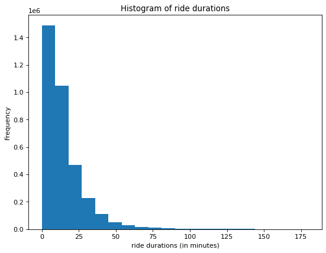

```python
#Firstly we create the column "duration_in_minutes"
import warnings
warnings.filterwarnings('ignore')
df_less_than_3_hours['duration_in_minutes'] = df_less_than_3_hours['duration_in_seconds']/60
#Plot the histogram
plt.figure(figsize=(8, 6), dpi=80)
plt.hist(df_less_than_3_hours['duration_in_minutes'], bins = 20)
plt.title("Histogram of ride durations")
plt.ylabel("Frequency")
plt.xlabel("ride durations (in minutes)")
plt.show()
```

From the graph above, we can see that the duration of the rides follows a negative exponential distribution, starting with ride durations of 8 minutes with high frequency, 16 minutes with less frequency etc. The frequency of ride duration more than 75 minutes is close to 0.

## Question 2: What is the expected ride duration (i.e., the average ride duration)? What is the empirical variance of ride duration? What is the probability that a ride duration is greater than 20 min?

The expected ride duration can be calculated as

$\frac{Sum\:of\:duration\:of\:every\:ride}{number\:of\:all\:ride}$

The empirical variance of ride duration can be calculated as below

$\sigma^2 = \frac{\sum_{i=1}^{n}(d_i - \mu)^2} {n-1}$

While $d_i$ is the duration of every ride and $\mu$ is average ride duration

Lastly, the probability that a ride duration is greater than 20 min can be calculated as:

$\frac{number\:of\:rides\:with\:duration\:>20\:minute}{number\:of\:all\:ride}$

The result can be viewed as below

```python
print("The expected ride duration is", round(df_less_than_3_hours['duration_in_minutes'].mean(), 2),"minutes")
print("The empirical variance of ride duration is", round(df_less_than_3_hours['duration_in_minutes'].var(), 2))
dur_greater_20_min = len(df_less_than_3_hours[df_less_than_3_hours['duration_in_minutes'] > 20])/len(df_less_than_3_hours)
print("The probability that a ride duration is greater than 20 min is", round(dur_greater_20_min, 2))
```

```
The expected ride duration is 14.99 minutes
The empirical variance of ride duration is 232.81
The probability that a ride duration is greater than 20 min is 0.23
```

## Question 3: What is the probability that a ride duration is greater than 20 min conditioning on the fact that the user is a CitiBike member?

The probaility can be calculated as:

$\frac{number\:of\:ride\:from\:member\:and\:duration>=20}{number\:of\:all\:ride\:from\:member}$

The result can be viewed as below

```python
#Calculate no of rides that are from member and greater than 20 minutes
no_member_more_than_20 = len(df_less_than_3_hours[(df_less_than_3_hours['duration_in_minutes'] > 20)&\
                                                  (df_less_than_3_hours['member_casual'] == 'member')])
#Calculate no of rides that are from member
no_member = len(df_less_than_3_hours[(df_less_than_3_hours['member_casual'] == 'member')])
#Calculate the probability
print("the probability that a ride duration is greater than 20 min given that the user is a CitiBike member is", end ="")
print(" ",round(no_member_more_than_20/no_member,3))
```

```
the probability that a ride duration is greater than 20 min given that the user is a CitiBike member is  0.186
```

## Question 4: Suppose that the duration of some ride is more than 25min. What is the probability that this ride belongs to a CitiBike member?

The probability that we want to calculate is: P(rider=CitiBike member | duration>25 mins) and with Bayes Rule we have: $$=\frac{P(duration>25 mins | rider=CitiBike \: member) P(rider=CitiBike \: member)}{P(duration>25 mins | rider=CitiBike \: member) P(rider=CitiBike \: member) + P(duration>25 mins | rider=Casual) P(rider=Casual)}$$

Below we calculate each probability

$P(duration>25 mins | rider=CitiBike \: member)$ =

```python
#Calculate no of rides that are from member and greater than 25 minutes
no_member_more_than_25 = len(df_less_than_3_hours[(df_less_than_3_hours['duration_in_minutes'] > 25)&\
                                                  (df_less_than_3_hours['member_casual'] == 'member')])

#Calculate the probability
P_greater25_given_member = no_member_more_than_25/no_member
P_greater25_given_member
```

```
0.12233236933677137
```

$P(rider=CitiBike \: member)$ =

```python
P_member = no_member/len(df_less_than_3_hours)
P_member
```

```
0.7616874835708882
```

$P(duration>25 mins | rider=Casual)$ =

```python
#Calculate no of rides that are from member and greater than 25 minutes
no_casual_more_than_25 = len(df_less_than_3_hours[(df_less_than_3_hours['duration_in_minutes'] > 25)&\
                                                  (df_less_than_3_hours['member_casual'] == 'casual')])

#Calculate no of rides that are from casual
no_casual = len(df_less_than_3_hours[(df_less_than_3_hours['member_casual'] == 'casual')])

#Calculate the probability
P_greater25_given_casual = no_casual_more_than_25/no_casual
P_greater25_given_casual
```

```
0.2785968883965127
```

$P(rider=Casual)$ =

```python
P_casual = no_casual/len(df_less_than_3_hours)
P_casual
```

```
0.23831251642911175
```

Hence, we have that:

```python
P_member_given_greater25 = round(P_greater25_given_member * P_member / \
                                 (P_greater25_given_member * P_member + P_greater25_given_casual * P_casual), 3)
print('The probability that a ride belongs to CitiBike member given that the ride is more than 25 minutes is', \
      P_member_given_greater25)
```

```
The probability that a ride belongs to CitiBike member given that the ride is more than 25 minutes is 0.584
```

## Question 5: What is the expected ride duration of an electric bike? What is the expected ride duration of a classic bike?

The equation to calculate the expected value is: $E(X)= ΣX * P(X)$

Below, we calculated the total number of each rideable type, including classic, electric, and docked within the dataframe. We then calculated the number of electric and classic bike rides.

Finally, given this knowledge, we used the mean of electric bike rides and mean of classic bike rides to compute the expected ride duration of an electric and classic bike, respectively.

```python
print(df_less_than_3_hours ['rideable_type'].value_counts())
```

```
classic_bike     2622762
electric_bike     824950
docked_bike        36956
Name: rideable_type, dtype: int64
```

```python
no_electric_bike_rides = df_less_than_3_hours['rideable_type'].value_counts()['electric_bike']
no_classic_bike_rides = df_less_than_3_hours['rideable_type'].value_counts()['classic_bike']
no_docked_bike_rides = df_less_than_3_hours['rideable_type'].value_counts()['docked_bike']
print("The number of electric bike rides is",no_electric_bike_rides)
print("The number of classic bike rides is",no_classic_bike_rides)
```

```
The number of electric bike rides is 824950
The number of classic bike rides is 2622762
```

```python
expected_duration_electric = df_less_than_3_hours.loc[df_less_than_3_hours['rideable_type'] == 'electric_bike', 'duration_in_minutes'].mean()
expected_duration_classic = df_less_than_3_hours.loc[df_less_than_3_hours['rideable_type'] == 'classic_bike', 'duration_in_minutes'].mean()

print("The expected ride duration of an electric bike is", round(expected_duration_electric,2),"minutes")
print("The expected ride duration of a classic bike is", round(expected_duration_classic,2),"minutes")
```

```
The expected ride duration of an electric bike is 15.17 minutes
The expected ride duration of a classic bike is 14.73 minutes
```

## Question 6: Suppose that the duration of some ride is less than 10min. What is the probability that this ride uses an electric bike? What is the probability that this ride uses a classic bike? Comment on the results.

We used the two equations below (Baye's Rule) to calculate the probabilities. We then checked our computation by calculating the probabilities using a compact code format.

P(rideable type=electric bike | duration<10 mins) and with Bayes Rule we have: $$=\frac{P(duration<10 mins | electric \: bike \:) P(electric\: bike \:)}{P(duration<10 mins | electric \: bike \: ) P(electric \: bike \:) + P(duration<10 mins | classic) P(classic)\:) +P(duration<10 mins | docked) P(docked)}$$

P(rideable type=classic bike | duration<10 mins) and with Bayes Rule we have: $$=\frac{P(duration<10 mins | classic \: bike \:) P(classic\: bike \:)}{P(duration<10 mins | classic \: bike \: ) P(classic \: bike \:) + P(duration<10 mins | electric) P(electric)\:) +P(duration<10 mins | docked) P(docked)}$$

Calculate the probailities as shown below:

```python
prob_duration_given_electric = \
df_less_than_3_hours[\
    (df_less_than_3_hours['duration_in_minutes']< 10) \
    & (df_less_than_3_hours['rideable_type']== "electric_bike")].shape[0]\
/df_less_than_3_hours[df_less_than_3_hours['rideable_type']== "electric_bike"].shape[0]

prob_electric = df_less_than_3_hours[df_less_than_3_hours['rideable_type']== "electric_bike"].shape[0] \
/df_less_than_3_hours.shape[0]

prob_duration_given_classic = \
df_less_than_3_hours[\
                     (df_less_than_3_hours['duration_in_minutes']< 10)\
                     & (df_less_than_3_hours['rideable_type']== "classic_bike")].shape[0]\
/df_less_than_3_hours[df_less_than_3_hours['rideable_type']== "classic_bike"].shape[0]

prob_classic = df_less_than_3_hours[df_less_than_3_hours['rideable_type']== "classic_bike"].shape[0] \
/df_less_than_3_hours.shape[0]

prob_duration_given_docked = \
df_less_than_3_hours[\
    (df_less_than_3_hours['duration_in_minutes']< 10) \
    & (df_less_than_3_hours['rideable_type']== "docked_bike")].shape[0]\
/df_less_than_3_hours[df_less_than_3_hours['rideable_type']== "docked_bike"].shape[0]

prob_docked = df_less_than_3_hours[df_less_than_3_hours['rideable_type']== "docked_bike"].shape[0] \
/df_less_than_3_hours.shape[0]

prob_classic_given_duration = round((prob_duration_given_classic*prob_classic)\
/(prob_duration_given_classic*prob_classic+prob_duration_given_electric*prob_electric+\
 prob_duration_given_docked*prob_docked),3)

prob_electric_given_duration = round((prob_duration_given_electric*prob_electric)\
/(prob_duration_given_classic*prob_classic+prob_duration_given_electric*prob_electric+\
 prob_duration_given_docked*prob_docked),3)

print(f"P(electric bike| duration<10min) = {prob_electric_given_duration}")
print(f"P(classic bike| duration<10min) = {prob_classic_given_duration}")
```

```
P(electric bike| duration<10min) = 0.234
P(classic bike| duration<10min) = 0.763
```

#### Comment on the results:

The probability of a ride belonging to a classic bike given that it's <10 minutes is higher than the probability of a ride belonging to an electric bike given that it's <10 minutes (about 3 times higher). This tells us that most customers choose to ride a classic bike instead of an electric bike, when they are riding for a short period of time. This can be due to the fact that using an electric bike is more costly than using a classic bike. The other reason can be due to the fact that there are more available classic bikes than electric bikes.

# Methodology, Analysis, and Results

## Section 1: Pre-processing of the data

### Remove holiday and weekend

For the preprocessing, we will remove the rows that refer to the weekends and the holidays of that month (4th of July). Because the availability of bikes in the stations will be different during these days. Afterwards we will define morning and evening slots.

First, we will drop the rows that refer to weekends and holidays (4th of July)

```python
# convert columns started_at and ended_at to datetime
df_less_than_3_hours['started_at'] = pd.to_datetime(df_less_than_3_hours['started_at'])
df_less_than_3_hours['ended_at'] = pd.to_datetime(df_less_than_3_hours['ended_at'])
```

```python
# drop weekends -> 2376170 rows
df_less_than_3_hours_weekdays = df_less_than_3_hours[~df_less_than_3_hours['started_at'].dt.weekday.isin([5,6])]
```

```python
# drop holidays (4th of July) -> 2279373 rows
df_less_than_3_hours_weekdays_no_holidays = \
                df_less_than_3_hours_weekdays[df_less_than_3_hours_weekdays['started_at'].dt.day != 4]
```

```python
df_less_than_3_hours_weekdays_no_holidays.head(5)
```

|  | ride_id | rideable_type | started_at | ended_at | start_station_name | start_station_id | end_station_name | end_station_id | start_lat | start_lng | end_lat | end_lng | member_casual | duration | duration_in_seconds | duration_in_minutes |
| --- | --- | --- | --- | --- | --- | --- | --- | --- | --- | --- | --- | --- | --- | --- | --- | --- |
| 1 | 374630DB5822C392 | electric_bike | 2022-07-29 18:19:08 | 2022-07-29 18:26:50 | E 68 St & 3 Ave | 6896.16 | E 85 St & York Ave | 7146.04 | 40.767128 | -73.962246 | 40.775369 | -73.948034 | member | 0 days 00:07:42 | 462.0 | 7.700000 |
| 4 | 44D0987673B9997D | classic_bike | 2022-07-11 07:56:29 | 2022-07-11 07:59:15 | E 68 St & 3 Ave | 6896.16 | E 66 St & Madison Ave | 6969.08 | 40.767128 | -73.962246 | 40.768009 | -73.968453 | member | 0 days 00:02:46 | 166.0 | 2.766667 |
| 5 | A80F03B56110AFF8 | classic_bike | 2022-07-14 19:35:53 | 2022-07-14 19:50:06 | Clinton Ave & Flushing Ave | 4762.04 | Bergen St & 4 Ave | 4322.06 | 40.697940 | -73.969868 | 40.682564 | -73.979898 | member | 0 days 00:14:13 | 853.0 | 14.216667 |
| 6 | D967C4FDF71ADE61 | classic_bike | 2022-07-26 20:18:17 | 2022-07-26 20:26:57 | E 68 St & 3 Ave | 6896.16 | E 85 St & York Ave | 7146.04 | 40.767128 | -73.962246 | 40.775369 | -73.948034 | member | 0 days 00:08:40 | 520.0 | 8.666667 |
| 7 | 62DA916392DE2A17 | electric_bike | 2022-07-13 06:46:50 | 2022-07-13 06:50:26 | E 89 St & York Ave | 7204.08 | E 85 St & York Ave | 7146.04 | 40.777945 | -73.946041 | 40.775369 | -73.948034 | member | 0 days 00:03:36 | 216.0 | 3.600000 |

### Split the morning and the evening

We will define the two slots. We say that the morning slot is 7 am - 11 am and the evening slot is 4 pm - 8 pm.

This strategy was used to define the morning and evening slots because:

- The morning hours and the evening hours could follow a certain pattern each.
- 7am-11am is usually the time that people go to work/start their day. We did not want the data from previous hours to affect the study presented in this report. Similarily, the evening slot from 4pm-8pm is usually when people are commuting back home/leaving work.
- We considered this as part of cleaning the data, similar to how the weekends and holidays were removed from the data.

Note that for the morning and evening slots, we kept the trips that started before the slot and ended in each slot and respectively started in the slot and ended after the slot. We will use these trips for the availability in the slot - in and out respectively.

```python
start_morning = datetime.strptime('07:00:00',"%H:%M:%S").time()
end_morning = datetime.strptime('11:00:00',"%H:%M:%S").time()
start_evening = datetime.strptime('16:00:00',"%H:%M:%S").time()
end_evening = datetime.strptime('20:00:00',"%H:%M:%S").time()
```

```python
df_morning = df_less_than_3_hours_weekdays_no_holidays[\
            (df_less_than_3_hours_weekdays_no_holidays['ended_at'].dt.time > start_morning) \
            & (df_less_than_3_hours_weekdays_no_holidays['started_at'].dt.time < end_morning)]
df_morning.head(5)
```

|  | ride_id | rideable_type | started_at | ended_at | start_station_name | start_station_id | end_station_name | end_station_id | start_lat | start_lng | end_lat | end_lng | member_casual | duration | duration_in_seconds | duration_in_minutes |
| --- | --- | --- | --- | --- | --- | --- | --- | --- | --- | --- | --- | --- | --- | --- | --- | --- |
| 4 | 44D0987673B9997D | classic_bike | 2022-07-11 07:56:29 | 2022-07-11 07:59:15 | E 68 St & 3 Ave | 6896.16 | E 66 St & Madison Ave | 6969.08 | 40.767128 | -73.962246 | 40.768009 | -73.968453 | member | 0 days 00:02:46 | 166.0 | 2.766667 |
| 16 | 0B4168237A91DCFA | classic_bike | 2022-07-15 10:49:49 | 2022-07-15 10:55:03 | Perry St & Bleecker St | 5922.07 | 6 Ave & Broome St | 5610.09 | 40.735418 | -74.004157 | 40.724310 | -74.004730 | member | 0 days 00:05:14 | 314.0 | 5.233333 |
| 23 | 834A2C3E3A6C9C3B | classic_bike | 2022-07-15 07:36:42 | 2022-07-15 07:38:09 | 30 Ave & 41 St | 6812.06 | 38 St & 30 Ave | 6850.01 | 40.763422 | -73.914142 | 40.764175 | -73.915840 | member | 0 days 00:01:27 | 87.0 | 1.450000 |
| 24 | 7926600DBE5E9896 | classic_bike | 2022-07-28 07:48:44 | 2022-07-28 07:50:23 | 30 Ave & 41 St | 6812.06 | 38 St & 30 Ave | 6850.01 | 40.763422 | -73.914142 | 40.764175 | -73.915840 | member | 0 days 00:01:39 | 99.0 | 1.650000 |
| 49 | 6740127962018D33 | classic_bike | 2022-07-29 09:46:43 | 2022-07-29 09:58:36 | Congress St & Clinton St | 4455.1 | Carlton Ave & Dean St | 4199.12 | 40.688255 | -73.995452 | 40.680974 | -73.971010 | member | 0 days 00:11:53 | 713.0 | 11.883333 |

```python
df_evening = df_less_than_3_hours_weekdays_no_holidays[\
            (df_less_than_3_hours_weekdays_no_holidays['ended_at'].dt.time > start_evening) \
            & (df_less_than_3_hours_weekdays_no_holidays['started_at'].dt.time < end_evening)]
df_evening.head(5)
```

|  | ride_id | rideable_type | started_at | ended_at | start_station_name | start_station_id | end_station_name | end_station_id | start_lat | start_lng | end_lat | end_lng | member_casual | duration | duration_in_seconds | duration_in_minutes |
| --- | --- | --- | --- | --- | --- | --- | --- | --- | --- | --- | --- | --- | --- | --- | --- | --- |
| 1 | 374630DB5822C392 | electric_bike | 2022-07-29 18:19:08 | 2022-07-29 18:26:50 | E 68 St & 3 Ave | 6896.16 | E 85 St & York Ave | 7146.04 | 40.767128 | -73.962246 | 40.775369 | -73.948034 | member | 0 days 00:07:42 | 462.0 | 7.700000 |
| 5 | A80F03B56110AFF8 | classic_bike | 2022-07-14 19:35:53 | 2022-07-14 19:50:06 | Clinton Ave & Flushing Ave | 4762.04 | Bergen St & 4 Ave | 4322.06 | 40.697940 | -73.969868 | 40.682564 | -73.979898 | member | 0 days 00:14:13 | 853.0 | 14.216667 |
| 15 | 7D8E808278B86CBC | electric_bike | 2022-07-08 18:43:09 | 2022-07-08 19:07:43 | 35 St & Broadway | 6750.16 | Engert Ave & McGuinness Blvd | 5473.03 | 40.760339 | -73.922243 | 40.721580 | -73.945460 | member | 0 days 00:24:34 | 1474.0 | 24.566667 |
| 26 | F8E62ADB163194F5 | classic_bike | 2022-07-21 16:52:27 | 2022-07-21 17:08:42 | Centre St & Worth St | 5279.03 | 6 Ave & Broome St | 5610.09 | 40.714948 | -74.002345 | 40.724310 | -74.004730 | member | 0 days 00:16:15 | 975.0 | 16.250000 |
| 28 | 078FF56D25065E0F | classic_bike | 2022-07-11 18:05:29 | 2022-07-11 18:11:51 | Hudson St & Reade St | 5359.1 | 6 Ave & Broome St | 5610.09 | 40.716250 | -74.009106 | 40.724310 | -74.004730 | member | 0 days 00:06:22 | 382.0 | 6.366667 |

Next, we will choose 3 stations that are popular

## Section 2: Select the station for the analysis

To select 3 stations for our analysis, we studied the activity of bikes entering and leaving stations during the defined morning and evening time frames.

As shown below, we then displayed the 10 busiest (most activity happening) stations and picked 3 that seem to be popular during the morning and evening hours and defined the capacity of each station (available docks) based on Google Maps as well as the CitiBike application.

```python
df_morning['start_station_name'].value_counts().sort_values(ascending=False).head(10)
```

```
E 33 St & 1 Ave       2213
1 Ave & E 68 St       2140
8 Ave & W 31 St       2020
W 54 St & 11 Ave      1886
W 21 St & 6 Ave       1805
Broadway & W 58 St    1747
E 40 St & Park Ave    1738
6 Ave & W 33 St       1593
E 72 St & York Ave    1568
9 Ave & W 22 St       1553
Name: start_station_name, dtype: int64
```

Explore the top 10 popular end stations, where people are bringing bikes to in the morning

```python
df_morning['end_station_name'].value_counts().sort_values(ascending=False).head(10)
```

```
1 Ave & E 68 St                      3470
E 47 St & Park Ave                   2684
Lafayette St & E 8 St                2475
W 21 St & 6 Ave                      2446
Broadway & W 25 St                   2392
E 40 St & Park Ave                   2310
Grand Army Plaza & Central Park S    2192
Broadway & E 21 St                   2158
W 42 St & 6 Ave                      2116
E 16 St & 5 Ave                      1985
Name: end_station_name, dtype: int64
```

Explore the top 10 popular stations, where people are taking bikes from and bringing bikes to in the morning

```python
popular_stations_morning=(df_morning['start_station_name'].value_counts() + df_morning['end_station_name']\
 .value_counts()).sort_values(ascending=False).head(10)
popular_stations_morning
```

```
1 Ave & E 68 St          5610.0
W 21 St & 6 Ave          4251.0
E 40 St & Park Ave       4048.0
E 33 St & 1 Ave          4024.0
Lafayette St & E 8 St    3745.0
Broadway & W 25 St       3704.0
E 47 St & Park Ave       3607.0
W 42 St & 6 Ave          3587.0
West St & Chambers St    3468.0
Broadway & W 58 St       3434.0
dtype: float64
```

Plot the bar chart to see the stations with highest level of activity

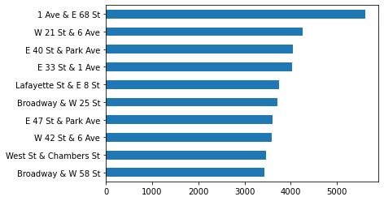

```python
popular_stations_morning.sort_values(ascending=True).plot(kind='barh');
```

### Explore Stations that are Popular in the Evening

Explore the top 10 popular start stations, where people are taking bikes out from in the evening.

```python
df_morning['start_station_name'].value_counts().sort_values(ascending=False).head(10)
df_evening['start_station_name'].value_counts().sort_values(ascending=False).head(10)
```

```
West St & Chambers St            4687
North Moore St & Greenwich St    3775
W 21 St & 6 Ave                  3628
Broadway & W 25 St               3489
1 Ave & E 68 St                  3380
6 Ave & W 33 St                  3182
Broadway & E 21 St               3168
West St & Liberty St             3064
Lafayette St & E 8 St            3058
E 16 St & 5 Ave                  2892
Name: start_station_name, dtype: int64
```

Explore the top 10 popular end stations, where people are bringing bikes to in the evening

```python
df_evening['end_station_name'].value_counts().sort_values(ascending=False).head(10)
```

```
West St & Chambers St       4346
6 Ave & W 33 St             3206
W 21 St & 6 Ave             3106
11 Ave & W 41 St            3095
12 Ave & W 40 St            2960
West St & Liberty St        2860
6 Ave & W 34 St             2666
Broadway & W 25 St          2618
9 Ave & W 22 St             2567
Cleveland Pl & Spring St    2538
Name: end_station_name, dtype: int64
```

Explore the top 10 popular stations, where people are taking bikes from and bringing bikes to in the evening

```python
 popular_stations_evening=(df_evening['start_station_name'].value_counts() + df_evening['end_station_name']\
 .value_counts()).sort_values(ascending=False).head(10)
popular_stations_evening
```

```
West St & Chambers St            9033.0
W 21 St & 6 Ave                  6734.0
6 Ave & W 33 St                  6388.0
Broadway & W 25 St               6107.0
West St & Liberty St             5924.0
11 Ave & W 41 St                 5858.0
Broadway & E 21 St               5602.0
6 Ave & W 34 St                  5438.0
12 Ave & W 40 St                 5374.0
North Moore St & Greenwich St    5370.0
dtype: float64
```

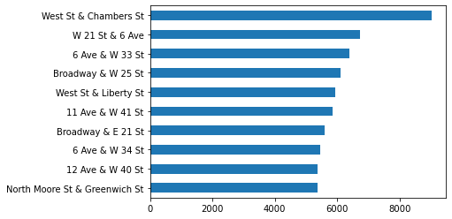

```python
popular_stations_evening.sort_values(ascending=True).plot(kind='barh');
```

### From the plot above, the 3 stations we will use in the project are:

```
1. West St & Chambers St  (79 bike docking stations)
2. W 21 St & 6 Ave (72 bike docking stations)
3. Broadway & E 21 St (60 bike docking stations)
```

## Section 3: Time Discretization

To decide how long a state should be, we have a criteria as below:

1. The state should long enough that we can observe a consider amount of activity in one state.
2. The state should not last too long that there are significant difference among each state.

Keeping the criteria in mind, we will try to see the activity level of 10-minute state and 15-minute state and decide which is better for our used case.

#### Step 1: For simplicity, write a function that get the dataframe, duration of the state and output a table that's similar to the structure below

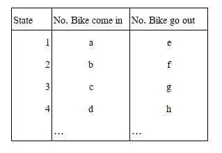

```python
def create_markov_table(station_name, mins, df, morning):
    #if it's morning then input 1
    #Mins is the number of minutes in each state
    period = mins
    n_state_day = 240/period
    df_station = df[(df['end_station_name']== station_name)|(df['start_station_name']==station_name)]
    date_drop_holiday_weekend = [1,5,6,7,8,11,12,13,14,15,18,19,20,21,22,25,26,27,28,29]
    markov_time = []
    out_list = []
    in_list = []
    if morning == 1:
        time_start = 7
    else:
        time_start = 16
    for d in date_drop_holiday_weekend:
        beginning_day_time = datetime(2022, 7, d, time_start, 0, 0, 0)
        for i in range(int(n_state_day)):
            num_in = 0
            num_out = 0
            time_in_state = beginning_day_time.timestamp()+i*period*60
            markov_time.append(datetime.fromtimestamp(time_in_state).strftime("%m/%d %H:%M:%S"))
            for index, row in df_station.iterrows():

                if ((beginning_day_time.timestamp()+i*period*60 < row['ended_at'].timestamp()+60*4*60) &
                    (beginning_day_time.timestamp()+(i+1)*period*60 > row['ended_at'].timestamp()+60*4*60)):
                    num_in +=1

                elif ((beginning_day_time.timestamp()+i*period*60 < row['started_at'].timestamp()+60*4*60) &
                      (beginning_day_time.timestamp()+(i+1)*period*60 > row['started_at'].timestamp()+60*4*60)):
                      num_out +=1
            out_list.append(num_out)
            in_list.append(num_in)
    if morning ==1:
        print("The dataframe for",station_name,"_morning was constructed")
    else:
        print("The dataframe for",station_name,"_evening was constructed")
    return pd.DataFrame({'time': markov_time,'In':in_list,'out':out_list})
```

#### Next, we compared the activity between using 10-minutes state and 15-minute state, as shown below.

In the next block of code, we will use the function to construct the dataframe described above. The dataframe will also be used to calculate the Transition Matrix and Stationary Distribution.

### Please note that the run time of the below block of code is around 35 minutes.

```python
#Feel free to skip this one to save time
df_West_St_morning = create_markov_table('West St & Chambers St', 10, df_morning, 1)
df_West_St_evening = create_markov_table('West St & Chambers St', 10, df_evening, 0)

df_W_21_morning = create_markov_table('W 21 St & 6 Ave', 10, df_morning, 1)
df_W_21_evening = create_markov_table('W 21 St & 6 Ave', 10, df_evening, 0)

df_Broadway_morning = create_markov_table('Broadway & E 21 St', 10, df_morning, 1)
df_Broadway_evening = create_markov_table('Broadway & E 21 St', 10, df_evening, 0)
```

```
The dataframe for West St & Chambers St _morning was constructed
The dataframe for West St & Chambers St _evening was constructed
The dataframe for W 21 St & 6 Ave _morning was constructed
The dataframe for W 21 St & 6 Ave _evening was constructed
The dataframe for Broadway & E 21 St _morning was constructed
The dataframe for Broadway & E 21 St _evening was constructed
```

#### Example of the dataframe created:

```python
df_Broadway_evening
```

|  | time | In | out |
| --- | --- | --- | --- |
| 0 | 07/01 16:00:00 | 10 | 9 |
| 1 | 07/01 16:10:00 | 14 | 5 |
| 2 | 07/01 16:20:00 | 3 | 6 |
| 3 | 07/01 16:30:00 | 9 | 3 |
| 4 | 07/01 16:40:00 | 5 | 3 |
| 5 | 07/01 16:50:00 | 3 | 1 |
| 6 | 07/01 17:00:00 | 5 | 7 |
| 7 | 07/01 17:10:00 | 7 | 7 |
| 8 | 07/01 17:20:00 | 11 | 9 |
| 9 | 07/01 17:30:00 | 10 | 8 |
| 10 | 07/01 17:40:00 | 10 | 7 |
| 11 | 07/01 17:50:00 | 11 | 12 |
| 12 | 07/01 18:00:00 | 9 | 9 |
| 13 | 07/01 18:10:00 | 7 | 4 |
| 14 | 07/01 18:20:00 | 2 | 4 |
| 15 | 07/01 18:30:00 | 15 | 14 |
| 16 | 07/01 18:40:00 | 13 | 6 |
| 17 | 07/01 18:50:00 | 8 | 14 |
| 18 | 07/01 19:00:00 | 13 | 4 |
| 19 | 07/01 19:10:00 | 4 | 4 |
| 20 | 07/01 19:20:00 | 9 | 9 |
| 21 | 07/01 19:30:00 | 6 | 4 |
| 22 | 07/01 19:40:00 | 11 | 7 |
| 23 | 07/01 19:50:00 | 3 | 3 |
| 24 | 07/05 16:00:00 | 10 | 8 |
| 25 | 07/05 16:10:00 | 11 | 5 |
| 26 | 07/05 16:20:00 | 9 | 4 |
| 27 | 07/05 16:30:00 | 6 | 4 |
| 28 | 07/05 16:40:00 | 8 | 2 |
| 29 | 07/05 16:50:00 | 4 | 8 |

[output cut: 450 more lines]

### Next, we will construct the same dataframe but for the 15-minute state.

Please note that at the end, we will reach the conclusion that the 10-minute state is better.

### Please note that the run time of the below block of code is around 20 minutes.

```python
#Get all the 15 minutes data frame
df_West_St_morning_15 = create_markov_table('West St & Chambers St', 15, df_morning, 1)
df_West_St_evening_15 = create_markov_table('West St & Chambers St', 15, df_evening, 0)

df_W_21_morning_15 = create_markov_table('W 21 St & 6 Ave', 15, df_morning, 1)
df_W_21_evening_15 = create_markov_table('W 21 St & 6 Ave', 15, df_evening, 0)

df_Broadway_morning_15 = create_markov_table('Broadway & E 21 St', 15, df_morning, 1)
df_Broadway_evening_15 = create_markov_table('Broadway & E 21 St', 15, df_evening, 0)
```

```
The dataframe for West St & Chambers St _morning was constructed
The dataframe for West St & Chambers St _evening was constructed
The dataframe for W 21 St & 6 Ave _morning was constructed
The dataframe for W 21 St & 6 Ave _evening was constructed
The dataframe for Broadway & E 21 St _morning was constructed
The dataframe for Broadway & E 21 St _evening was constructed
```

#### We then compare the level of activity between the 10-minute state and 15-minute state for each station, as show below, to see the difference.

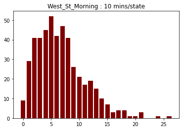

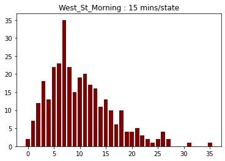

```python
#10 minutes df
df_count = df_West_St_morning.In.value_counts().rename_axis('unique_values').reset_index(name='counts')
plt.bar(df_count.unique_values, df_count.counts, color ='maroon',width = 0.8)
plt.title("West_St_Morning : 10 mins/state")
plt.show()
df_count = df_West_St_morning_15.In.value_counts().rename_axis('unique_values').reset_index(name='counts')
plt.bar(df_count.unique_values, df_count.counts, color ='maroon',width = 0.8)
plt.title("West_St_Morning : 15 mins/state")
plt.show()
```

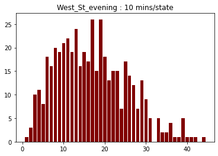

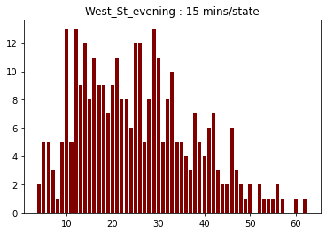

```python
#10 minutes df
df_count = df_West_St_evening.In.value_counts().rename_axis('unique_values').reset_index(name='counts')
plt.bar(df_count.unique_values, df_count.counts, color ='maroon',width = 0.8)
plt.title("West_St_evening : 10 mins/state")
plt.show()
df_count = df_West_St_evening_15.In.value_counts().rename_axis('unique_values').reset_index(name='counts')
plt.bar(df_count.unique_values, df_count.counts, color ='maroon',width = 0.8)
plt.title("West_St_evening : 15 mins/state")
plt.show()
```

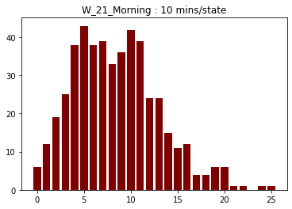

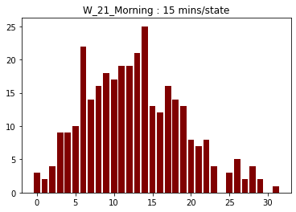

```python
#10 minutes df
df_count = df_W_21_morning.In.value_counts().rename_axis('unique_values').reset_index(name='counts')
plt.bar(df_count.unique_values, df_count.counts, color ='maroon',width = 0.8)
plt.title("W_21_Morning : 10 mins/state")
plt.show()
df_count = df_W_21_morning_15.In.value_counts().rename_axis('unique_values').reset_index(name='counts')
plt.bar(df_count.unique_values, df_count.counts, color ='maroon',width = 0.8)
plt.title("W_21_Morning : 15 mins/state")
plt.show()
```

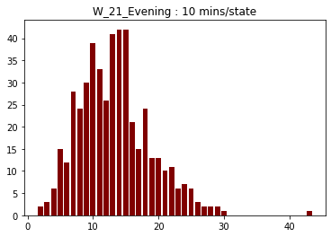

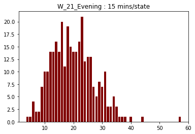

```python
#10 minutes df
df_count = df_W_21_evening.In.value_counts().rename_axis('unique_values').reset_index(name='counts')
plt.bar(df_count.unique_values, df_count.counts, color ='maroon',width = 0.8)
plt.title("W_21_Evening : 10 mins/state")
plt.show()
df_count = df_W_21_evening_15.In.value_counts().rename_axis('unique_values').reset_index(name='counts')
plt.bar(df_count.unique_values, df_count.counts, color ='maroon',width = 0.8)
plt.title("W_21_Evening : 15 mins/state")
plt.show()
```

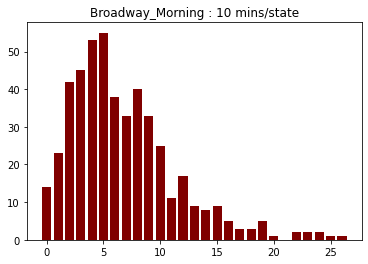

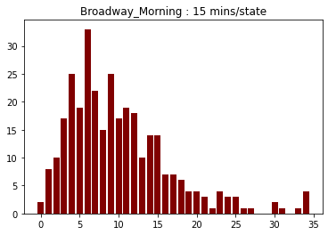

```python
#10 minutes df
df_count = df_Broadway_morning.In.value_counts().rename_axis('unique_values').reset_index(name='counts')
plt.bar(df_count.unique_values, df_count.counts, color ='maroon',width = 0.8)
plt.title("Broadway_Morning : 10 mins/state")
plt.show()
df_count = df_Broadway_morning_15.In.value_counts().rename_axis('unique_values').reset_index(name='counts')
plt.bar(df_count.unique_values, df_count.counts, color ='maroon',width = 0.8)
plt.title("Broadway_Morning : 15 mins/state")
plt.show()
```

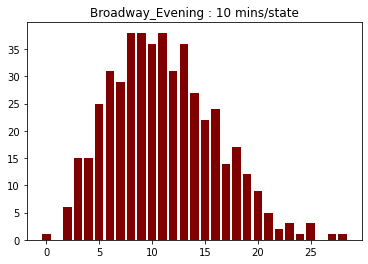

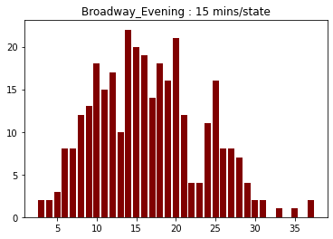

```python
#10 minutes df
df_count = df_Broadway_evening.In.value_counts().rename_axis('unique_values').reset_index(name='counts')
plt.bar(df_count.unique_values, df_count.counts, color ='maroon',width = 0.8)
plt.title("Broadway_Evening : 10 mins/state")
plt.show()
df_count = df_Broadway_evening_15.In.value_counts().rename_axis('unique_values').reset_index(name='counts')
plt.bar(df_count.unique_values, df_count.counts, color ='maroon',width = 0.8)
plt.title("Broadway_Evening : 15 mins/state")
plt.show()
```

#### Conclusively, we defined our descritized time step for our Markov Chain analysis to be 10 minutes. As seen in the 12 plots above, the 10 minutes for every station/time has data that is more evenly spread with enough activity in one state.

## Section 4: Estimation of Availability of Bikes in the Begining of July 1st and Every Day After

The initial state of the MC will be computed by following the method described below, for each time slot of each station. More specifically, we implemented this method for the estimation of available bikes in the beginning of each time slot (morning-evening) for each day and for every station. For this, we used the dataframe that is explained above for each time slot (morning-evening) and for every station (so in total we did it 6 times) and the capacity of each station. The capacity for the selected stations was estimated using the CitiBike application. Finding the stations at the application, we are able to see the classic and ebikes and the open docks. The summation of these provides the capacity of each station:

The capacity of West St. & Chambers St. Station is 79 bikes

The capacity of Westi 21 & 6th Avenue id 72 bikes

The capacity of Broadway and East 21 is 60 bikes

Having the above, we are using the dataframes of each time-slot (morning-evening) and the capacity of each station as inputs in a function (named get_df_with_availabilities) to create a column in the dataframes that has the availability at each 10-minutes slot. In this function, we are calculating the average “In” minus “Out”, and subtracting that from half the capacity. We round this number and assume that it is the available bikes right before this time-slot (i.e., morning or evening). This is because, statistically, if we didn't have any information, we would use just half of the capacity, but since we have ins and outs, we will use them to have an equilibrium for half of the capacity. Afterwards, we check if the availability at some 10-minutes slot exceeds the capacity or if the availability has a negative value, since the availability before the time-slot was a high-level estimation. We deal with the first occasion by subtracting the difference between the capacity and the maximum availability from the initial availability. Respectively, we deal with the second occasion by adding the absolute value of the most negative value of availability that occurs in that morning/evening time-slot. We do this procedure for all of the days - we compute the available bikes from the start for all days.

There were some occasions where the available bikes happened to have a negative value. We are assuming that this occurs, because some bikes are being manually moved to some stations and the data in these specific occasions (time slots) and these stations do not satisfy the constraints that at all stages the available bikes must be non-negative and less than the capacity. We are sure that they will not have a number greater than the capacity, since the constraint in the function described above first deals with the occasion that availability is greater than the capacity. In order to deal with this, we created a function (named change_range), that takes the morning/evening time-slots that this occurs and sets the range of availability to be equal to the capacity while maintaining the distribution (e.g., maintaining the fraction moving from one state to the next).

Finally, we check the maximum and minimum availability in each dataframe to make sure that they are non-negative and less than the capacity.

```python
def get_availabilities_i_plus1_to_end_slot(df, i):
    for j in range(i+1, i+24):
        df.iloc[j, 3] = df.iloc[j-1, 3] + df.iloc[j, 1] - df.iloc[j, 2]
    return (df)
```

```python
def get_df_with_availabilities(df, capacity):
    df['availability'] = np.nan
    i=0
    df.reset_index(drop=True, inplace=True)
    while i < 480:
        half = capacity/2
        temp = df.copy()
        temp = temp[i:i+24]
        temp['in_minus_out'] = temp.In - temp.out
        mean_in_minus_out = temp['in_minus_out'].mean()
        availabity_before_slot = half - mean_in_minus_out
        df.iloc[i, 3] = round(availabity_before_slot) + df.iloc[i, 1] - df.iloc[i, 2]
        df = get_availabilities_i_plus1_to_end_slot(df, i)
        if df[i: i+24]['availability'].max() > capacity:
            df.iloc[i, 3] = df.iloc[i, 3] - df[i: i+24]['availability'].max() + capacity
            df = get_availabilities_i_plus1_to_end_slot(df, i)
        elif df[i: i+24]['availability'].min() < 0:
            df.iloc[i, 3] = df.iloc[i, 3] + abs(df[i: i+24]['availability'].min())
            df = get_availabilities_i_plus1_to_end_slot(df, i)

        i += 24
    return (df)
```

```python
def change_range(df, lista, capacity):
    for j in lista:
        old_range = df[j:j+24].availability.max() - df[j:j+24].availability.min()
        new_range = capacity
        old_min = df[j:j+24].availability.min()
        new_min = 0
        for i in df[j:j+24].index:
            df.iloc[i,3] = round((((df.iloc[i,3] - old_min) * new_range) / old_range) + new_min)
    return (df)
```

### West and Chambers

#### Morning West and Chambers

```python
df_west_st_chambers_morning = pd.read_csv('df_West_St_morning.csv')
west_st_chambers_capacity = 79
df_west_st_chambers_morning.drop('Unnamed: 0', axis=1, inplace=True)
FMT = '%m/%d %H:%M:%S'
df_west_st_chambers_morning.time = df_west_st_chambers_morning.time.apply(lambda x: datetime.strptime(x, FMT))
df_west_st_chambers_morning['time'] = df_west_st_chambers_morning['time'].apply(lambda x: x.replace(year = 2022))
df_west_st_chambers_morning_with_availability = get_df_with_availabilities(df_west_st_chambers_morning, west_st_chambers_capacity)
```

Check if the availability is within the constraints between non-negative values and less than the capacity:

```python
df_west_st_chambers_morning_with_availability.availability.min()
```

```
30.0
```

```python
df_west_st_chambers_morning_with_availability.availability.max()
```

```
75.0
```

```python
df_west_st_chambers_morning_with_availability
```

|  | time | In | out | availability |
| --- | --- | --- | --- | --- |
| 0 | 2022-07-01 07:00:00 | 4 | 5 | 38.0 |
| 1 | 2022-07-01 07:10:00 | 0 | 6 | 32.0 |
| 2 | 2022-07-01 07:20:00 | 4 | 3 | 33.0 |
| 3 | 2022-07-01 07:30:00 | 4 | 6 | 31.0 |
| 4 | 2022-07-01 07:40:00 | 9 | 2 | 38.0 |
| 5 | 2022-07-01 07:50:00 | 7 | 3 | 42.0 |
| 6 | 2022-07-01 08:00:00 | 1 | 3 | 40.0 |
| 7 | 2022-07-01 08:10:00 | 4 | 4 | 40.0 |
| 8 | 2022-07-01 08:20:00 | 7 | 9 | 38.0 |
| 9 | 2022-07-01 08:30:00 | 9 | 6 | 41.0 |
| 10 | 2022-07-01 08:40:00 | 7 | 4 | 44.0 |
| 11 | 2022-07-01 08:50:00 | 8 | 4 | 48.0 |
| 12 | 2022-07-01 09:00:00 | 2 | 7 | 43.0 |
| 13 | 2022-07-01 09:10:00 | 8 | 4 | 47.0 |
| 14 | 2022-07-01 09:20:00 | 1 | 4 | 44.0 |
| 15 | 2022-07-01 09:30:00 | 5 | 5 | 44.0 |
| 16 | 2022-07-01 09:40:00 | 7 | 5 | 46.0 |
| 17 | 2022-07-01 09:50:00 | 6 | 4 | 48.0 |
| 18 | 2022-07-01 10:00:00 | 5 | 6 | 47.0 |
| 19 | 2022-07-01 10:10:00 | 7 | 3 | 51.0 |
| 20 | 2022-07-01 10:20:00 | 3 | 2 | 52.0 |
| 21 | 2022-07-01 10:30:00 | 7 | 4 | 55.0 |
| 22 | 2022-07-01 10:40:00 | 2 | 5 | 52.0 |
| 23 | 2022-07-01 10:50:00 | 7 | 8 | 51.0 |
| 24 | 2022-07-05 07:00:00 | 3 | 3 | 39.0 |
| 25 | 2022-07-05 07:10:00 | 7 | 4 | 42.0 |
| 26 | 2022-07-05 07:20:00 | 7 | 2 | 47.0 |
| 27 | 2022-07-05 07:30:00 | 0 | 3 | 44.0 |
| 28 | 2022-07-05 07:40:00 | 4 | 0 | 48.0 |
| 29 | 2022-07-05 07:50:00 | 1 | 3 | 46.0 |

[output cut: 450 more lines]

#### Evening West and Chambers

```python
df_west_st_chambers_ev = pd.read_csv('df_West_St_evening.csv')
df_west_st_chambers_ev.drop('Unnamed: 0', axis=1, inplace=True)
FMT = '%m/%d %H:%M:%S'
df_west_st_chambers_ev.time = df_west_st_chambers_ev.time.apply(lambda x: datetime.strptime(x, FMT))
df_west_st_chambers_ev['time'] = df_west_st_chambers_ev['time'].apply(lambda x: x.replace(year = 2022))
df_west_st_chambers_evening_with_availability = get_df_with_availabilities(df_west_st_chambers_ev, west_st_chambers_capacity)
```

Check if the availability is within the constraints between non-negative values and less than the capacity:

```python
df_west_st_chambers_evening_with_availability.availability.min()
```

```
0.0
```

```python
df_west_st_chambers_evening_with_availability.availability.max()
```

```
79.0
```

```python
df_west_st_chambers_evening_with_availability
```

|  | time | In | out | availability |
| --- | --- | --- | --- | --- |
| 0 | 2022-07-01 16:00:00 | 13 | 7 | 43.0 |
| 1 | 2022-07-01 16:10:00 | 14 | 14 | 43.0 |
| 2 | 2022-07-01 16:20:00 | 19 | 11 | 51.0 |
| 3 | 2022-07-01 16:30:00 | 4 | 14 | 41.0 |
| 4 | 2022-07-01 16:40:00 | 14 | 7 | 48.0 |
| 5 | 2022-07-01 16:50:00 | 11 | 7 | 52.0 |
| 6 | 2022-07-01 17:00:00 | 10 | 15 | 47.0 |
| 7 | 2022-07-01 17:10:00 | 13 | 14 | 46.0 |
| 8 | 2022-07-01 17:20:00 | 13 | 9 | 50.0 |
| 9 | 2022-07-01 17:30:00 | 17 | 10 | 57.0 |
| 10 | 2022-07-01 17:40:00 | 12 | 14 | 55.0 |
| 11 | 2022-07-01 17:50:00 | 10 | 18 | 47.0 |
| 12 | 2022-07-01 18:00:00 | 12 | 6 | 53.0 |
| 13 | 2022-07-01 18:10:00 | 17 | 4 | 66.0 |
| 14 | 2022-07-01 18:20:00 | 12 | 10 | 68.0 |
| 15 | 2022-07-01 18:30:00 | 12 | 16 | 64.0 |
| 16 | 2022-07-01 18:40:00 | 6 | 13 | 57.0 |
| 17 | 2022-07-01 18:50:00 | 19 | 11 | 65.0 |
| 18 | 2022-07-01 19:00:00 | 14 | 16 | 63.0 |
| 19 | 2022-07-01 19:10:00 | 6 | 14 | 55.0 |
| 20 | 2022-07-01 19:20:00 | 17 | 13 | 59.0 |
| 21 | 2022-07-01 19:30:00 | 26 | 11 | 74.0 |
| 22 | 2022-07-01 19:40:00 | 7 | 12 | 69.0 |
| 23 | 2022-07-01 19:50:00 | 15 | 5 | 79.0 |
| 24 | 2022-07-05 16:00:00 | 12 | 7 | 43.0 |
| 25 | 2022-07-05 16:10:00 | 12 | 6 | 49.0 |
| 26 | 2022-07-05 16:20:00 | 6 | 7 | 48.0 |
| 27 | 2022-07-05 16:30:00 | 10 | 7 | 51.0 |
| 28 | 2022-07-05 16:40:00 | 4 | 7 | 48.0 |
| 29 | 2022-07-05 16:50:00 | 11 | 4 | 55.0 |

[output cut: 450 more lines]

### W 21 & 6 Ave

#### Morning W 21 & 6 Ave

```python
df_west21_morning = pd.read_csv('df_W_21_morning.csv')
df_west21_morning.drop('Unnamed: 0', axis=1, inplace=True)
FMT = '%m/%d %H:%M:%S'
df_west21_morning.time = df_west21_morning.time.apply(lambda x: datetime.strptime(x, FMT))
df_west21_morning['time'] = df_west21_morning['time'].apply(lambda x: x.replace(year = 2022))
west21_capacity = 72
df_west21_morning_with_availability = get_df_with_availabilities(df_west21_morning, west21_capacity)
```

Check if the availability is within the constraints between non-negative values and less than the capacity:

```python
df_west21_morning_with_availability.availability.min()
```

```
2.0
```

```python
df_west21_morning_with_availability.availability.max()
```

```
72.0
```

```python
df_west21_morning_with_availability
```

|  | time | In | out | availability |
| --- | --- | --- | --- | --- |
| 0 | 2022-07-01 07:00:00 | 4 | 2 | 26.0 |
| 1 | 2022-07-01 07:10:00 | 3 | 0 | 29.0 |
| 2 | 2022-07-01 07:20:00 | 2 | 1 | 30.0 |
| 3 | 2022-07-01 07:30:00 | 2 | 2 | 30.0 |
| 4 | 2022-07-01 07:40:00 | 4 | 3 | 31.0 |
| 5 | 2022-07-01 07:50:00 | 3 | 8 | 26.0 |
| 6 | 2022-07-01 08:00:00 | 10 | 8 | 28.0 |
| 7 | 2022-07-01 08:10:00 | 6 | 4 | 30.0 |
| 8 | 2022-07-01 08:20:00 | 7 | 5 | 32.0 |
| 9 | 2022-07-01 08:30:00 | 10 | 7 | 35.0 |
| 10 | 2022-07-01 08:40:00 | 10 | 2 | 43.0 |
| 11 | 2022-07-01 08:50:00 | 5 | 3 | 45.0 |
| 12 | 2022-07-01 09:00:00 | 5 | 4 | 46.0 |
| 13 | 2022-07-01 09:10:00 | 11 | 3 | 54.0 |
| 14 | 2022-07-01 09:20:00 | 4 | 1 | 57.0 |
| 15 | 2022-07-01 09:30:00 | 3 | 5 | 55.0 |
| 16 | 2022-07-01 09:40:00 | 8 | 3 | 60.0 |
| 17 | 2022-07-01 09:50:00 | 6 | 8 | 58.0 |
| 18 | 2022-07-01 10:00:00 | 10 | 3 | 65.0 |
| 19 | 2022-07-01 10:10:00 | 10 | 9 | 66.0 |
| 20 | 2022-07-01 10:20:00 | 11 | 6 | 71.0 |
| 21 | 2022-07-01 10:30:00 | 6 | 5 | 72.0 |
| 22 | 2022-07-01 10:40:00 | 5 | 6 | 71.0 |
| 23 | 2022-07-01 10:50:00 | 3 | 3 | 71.0 |
| 24 | 2022-07-05 07:00:00 | 1 | 3 | 33.0 |
| 25 | 2022-07-05 07:10:00 | 2 | 0 | 35.0 |
| 26 | 2022-07-05 07:20:00 | 3 | 5 | 33.0 |
| 27 | 2022-07-05 07:30:00 | 4 | 1 | 36.0 |
| 28 | 2022-07-05 07:40:00 | 3 | 2 | 37.0 |
| 29 | 2022-07-05 07:50:00 | 4 | 2 | 39.0 |

[output cut: 450 more lines]

#### Evening W 21 & 6 Ave

```python
df_west21_evening = pd.read_csv('df_W_21_evening.csv')
df_west21_evening.drop('Unnamed: 0', axis=1, inplace=True)
FMT = '%m/%d %H:%M:%S'
df_west21_evening.time = df_west21_evening.time.apply(lambda x: datetime.strptime(x, FMT))
df_west21_evening['time'] = df_west21_evening['time'].apply(lambda x: x.replace(year = 2022))
west21_capacity = 72
df_west21_evening_with_availability = get_df_with_availabilities(df_west21_evening, west21_capacity)
```

```python
df_west21_evening_with_availability.availability.min()
```

```
-32.0
```

Now we will see the negative values, so we can deal with them by changing the range in that slot:

```python
df_west21_evening_with_availability[df_west21_evening_with_availability.availability < 0]
```

|  | time | In | out | availability |
| --- | --- | --- | --- | --- |
| 48 | 2022-07-06 16:00:00 | 13 | 7 | -10.0 |
| 49 | 2022-07-06 16:10:00 | 13 | 10 | -7.0 |
| 51 | 2022-07-06 16:30:00 | 5 | 9 | -3.0 |
| 52 | 2022-07-06 16:40:00 | 11 | 13 | -5.0 |
| 53 | 2022-07-06 16:50:00 | 12 | 14 | -7.0 |
| 54 | 2022-07-06 17:00:00 | 12 | 16 | -11.0 |
| 55 | 2022-07-06 17:10:00 | 20 | 15 | -6.0 |
| 72 | 2022-07-07 16:00:00 | 10 | 9 | -6.0 |
| 73 | 2022-07-07 16:10:00 | 13 | 8 | -1.0 |
| 120 | 2022-07-11 16:00:00 | 14 | 15 | -13.0 |
| 121 | 2022-07-11 16:10:00 | 13 | 7 | -7.0 |
| 122 | 2022-07-11 16:20:00 | 11 | 7 | -3.0 |
| 123 | 2022-07-11 16:30:00 | 9 | 10 | -4.0 |
| 124 | 2022-07-11 16:40:00 | 9 | 13 | -8.0 |
| 125 | 2022-07-11 16:50:00 | 17 | 16 | -7.0 |
| 126 | 2022-07-11 17:00:00 | 15 | 11 | -3.0 |
| 144 | 2022-07-12 16:00:00 | 11 | 9 | -5.0 |
| 145 | 2022-07-12 16:10:00 | 10 | 6 | -1.0 |
| 147 | 2022-07-12 16:30:00 | 3 | 15 | -8.0 |
| 168 | 2022-07-13 16:00:00 | 7 | 14 | -16.0 |
| 169 | 2022-07-13 16:10:00 | 15 | 11 | -12.0 |
| 170 | 2022-07-13 16:20:00 | 12 | 14 | -14.0 |
| 192 | 2022-07-14 16:00:00 | 10 | 11 | -6.0 |
| 193 | 2022-07-14 16:10:00 | 12 | 11 | -5.0 |
| 216 | 2022-07-15 16:00:00 | 9 | 9 | -6.0 |
| 240 | 2022-07-18 16:00:00 | 2 | 6 | -8.0 |
| 241 | 2022-07-18 16:10:00 | 5 | 5 | -8.0 |
| 242 | 2022-07-18 16:20:00 | 9 | 4 | -3.0 |
| 243 | 2022-07-18 16:30:00 | 6 | 4 | -1.0 |
| 244 | 2022-07-18 16:40:00 | 7 | 8 | -2.0 |
| 245 | 2022-07-18 16:50:00 | 11 | 11 | -2.0 |
| 264 | 2022-07-19 16:00:00 | 13 | 9 | -32.0 |
| 265 | 2022-07-19 16:10:00 | 16 | 10 | -26.0 |
| 266 | 2022-07-19 16:20:00 | 14 | 6 | -18.0 |
| 267 | 2022-07-19 16:30:00 | 9 | 6 | -15.0 |
| 268 | 2022-07-19 16:40:00 | 10 | 9 | -14.0 |
| 269 | 2022-07-19 16:50:00 | 13 | 12 | -13.0 |
| 270 | 2022-07-19 17:00:00 | 16 | 18 | -15.0 |
| 271 | 2022-07-19 17:10:00 | 15 | 8 | -8.0 |
| 272 | 2022-07-19 17:20:00 | 17 | 18 | -9.0 |
| 274 | 2022-07-19 17:40:00 | 17 | 23 | -6.0 |
| 288 | 2022-07-20 16:00:00 | 6 | 5 | -2.0 |
| 360 | 2022-07-25 16:00:00 | 5 | 8 | -13.0 |
| 361 | 2022-07-25 16:10:00 | 9 | 6 | -10.0 |
| 362 | 2022-07-25 16:20:00 | 10 | 6 | -6.0 |
| 363 | 2022-07-25 16:30:00 | 8 | 11 | -9.0 |
| 364 | 2022-07-25 16:40:00 | 13 | 6 | -2.0 |
| 365 | 2022-07-25 16:50:00 | 6 | 8 | -4.0 |
| 366 | 2022-07-25 17:00:00 | 6 | 7 | -5.0 |
| 367 | 2022-07-25 17:10:00 | 11 | 8 | -2.0 |
| 369 | 2022-07-25 17:30:00 | 8 | 15 | -4.0 |
| 388 | 2022-07-26 16:40:00 | 15 | 16 | -1.0 |
| 408 | 2022-07-27 16:00:00 | 10 | 11 | -20.0 |
| 409 | 2022-07-27 16:10:00 | 9 | 11 | -22.0 |
| 410 | 2022-07-27 16:20:00 | 16 | 13 | -19.0 |
| 411 | 2022-07-27 16:30:00 | 15 | 8 | -12.0 |
| 412 | 2022-07-27 16:40:00 | 11 | 9 | -10.0 |
| 413 | 2022-07-27 16:50:00 | 14 | 10 | -6.0 |
| 414 | 2022-07-27 17:00:00 | 12 | 14 | -8.0 |
| 415 | 2022-07-27 17:10:00 | 19 | 12 | -1.0 |
| 416 | 2022-07-27 17:20:00 | 8 | 19 | -12.0 |
| 417 | 2022-07-27 17:30:00 | 23 | 13 | -2.0 |
| 432 | 2022-07-28 16:00:00 | 11 | 10 | -14.0 |
| 433 | 2022-07-28 16:10:00 | 14 | 14 | -14.0 |
| 434 | 2022-07-28 16:20:00 | 15 | 5 | -4.0 |

```python
list_west21_evening = [48, 72, 120, 144, 168, 192, 216, 240, 264, 288, 360, 384, 408, 432]
```

```python
df_west21_evening_with_availability = change_range(df_west21_evening_with_availability, list_west21_evening, west21_capacity)
```

Check if the availability is within the constraints between non-negative values and less than the capacity:

```python
df_west21_evening_with_availability.availability.min()
```

```
0.0
```

```python
df_west21_evening_with_availability
```

|  | time | In | out | availability |
| --- | --- | --- | --- | --- |
| 0 | 2022-07-01 16:00:00 | 8 | 9 | 13.0 |
| 1 | 2022-07-01 16:10:00 | 15 | 6 | 22.0 |
| 2 | 2022-07-01 16:20:00 | 7 | 10 | 19.0 |
| 3 | 2022-07-01 16:30:00 | 8 | 8 | 19.0 |
| 4 | 2022-07-01 16:40:00 | 11 | 8 | 22.0 |
| 5 | 2022-07-01 16:50:00 | 16 | 8 | 30.0 |
| 6 | 2022-07-01 17:00:00 | 8 | 10 | 28.0 |
| 7 | 2022-07-01 17:10:00 | 13 | 9 | 32.0 |
| 8 | 2022-07-01 17:20:00 | 16 | 8 | 40.0 |
| 9 | 2022-07-01 17:30:00 | 8 | 8 | 40.0 |
| 10 | 2022-07-01 17:40:00 | 9 | 10 | 39.0 |
| 11 | 2022-07-01 17:50:00 | 11 | 9 | 41.0 |
| 12 | 2022-07-01 18:00:00 | 16 | 8 | 49.0 |
| 13 | 2022-07-01 18:10:00 | 17 | 11 | 55.0 |
| 14 | 2022-07-01 18:20:00 | 10 | 14 | 51.0 |
| 15 | 2022-07-01 18:30:00 | 17 | 10 | 58.0 |
| 16 | 2022-07-01 18:40:00 | 8 | 8 | 58.0 |
| 17 | 2022-07-01 18:50:00 | 7 | 13 | 52.0 |
| 18 | 2022-07-01 19:00:00 | 14 | 5 | 61.0 |
| 19 | 2022-07-01 19:10:00 | 11 | 10 | 62.0 |
| 20 | 2022-07-01 19:20:00 | 11 | 9 | 64.0 |
| 21 | 2022-07-01 19:30:00 | 14 | 10 | 68.0 |
| 22 | 2022-07-01 19:40:00 | 9 | 9 | 68.0 |
| 23 | 2022-07-01 19:50:00 | 11 | 7 | 72.0 |
| 24 | 2022-07-05 16:00:00 | 10 | 5 | 5.0 |
| 25 | 2022-07-05 16:10:00 | 8 | 8 | 5.0 |
| 26 | 2022-07-05 16:20:00 | 8 | 6 | 7.0 |
| 27 | 2022-07-05 16:30:00 | 9 | 14 | 2.0 |
| 28 | 2022-07-05 16:40:00 | 18 | 13 | 7.0 |
| 29 | 2022-07-05 16:50:00 | 11 | 3 | 15.0 |

[output cut: 450 more lines]

### Broadway

#### Morning Broadway

```python
df_broadway_morning = pd.read_csv('df_Broadway_morning.csv')
df_broadway_morning.drop('Unnamed: 0', axis=1, inplace=True)
FMT = '%m/%d %H:%M:%S'
df_broadway_morning.time = df_broadway_morning.time.apply(lambda x: datetime.strptime(x, FMT))
df_broadway_morning['time'] = df_broadway_morning['time'].apply(lambda x: x.replace(year = 2022))
broadway_capacity = 60
```

```python
df_broadway_morning_with_availability = get_df_with_availabilities(df_broadway_morning, broadway_capacity)
```

Check if the availability is within the constraints between non-negative values and less than the capacity:

```python
df_broadway_morning_with_availability.availability.min()
```

```
12.0
```

```python
df_broadway_morning_with_availability.availability.max()
```

```
60.0
```

#### Evening Broadway

```python
df_broadway_evening = pd.read_csv('df_Broadway_evening.csv')
df_broadway_evening.drop('Unnamed: 0', axis=1, inplace=True)
FMT = '%m/%d %H:%M:%S'
df_broadway_evening.time = df_broadway_evening.time.apply(lambda x: datetime.strptime(x, FMT))
df_broadway_evening['time'] = df_broadway_evening['time'].apply(lambda x: x.replace(year = 2022))
broadway_capacity = 60
```

```python
df_broadway_evening_with_availability = get_df_with_availabilities(df_broadway_evening, broadway_capacity)
```

Check if the availability is within the constraints between non-negative values and less than the capacity:

```python
df_broadway_evening_with_availability.availability.max()
```

```
60.0
```

```python
df_broadway_evening_with_availability.availability.min()
```

```
-25.0
```

Now we will see the negative values, so we can deal with them by changing the range in that slot:

```python
df_broadway_evening_with_availability[df_broadway_evening_with_availability.availability < 0]
```

|  | time | In | out | availability |
| --- | --- | --- | --- | --- |
| 77 | 2022-07-07 16:50:00 | 10 | 15 | -2.0 |
| 120 | 2022-07-11 16:00:00 | 6 | 5 | -18.0 |
| 121 | 2022-07-11 16:10:00 | 6 | 4 | -16.0 |
| 122 | 2022-07-11 16:20:00 | 11 | 7 | -12.0 |
| 123 | 2022-07-11 16:30:00 | 10 | 9 | -11.0 |
| 124 | 2022-07-11 16:40:00 | 8 | 7 | -10.0 |
| 125 | 2022-07-11 16:50:00 | 10 | 8 | -8.0 |
| 126 | 2022-07-11 17:00:00 | 15 | 17 | -10.0 |
| 127 | 2022-07-11 17:10:00 | 18 | 12 | -4.0 |
| 128 | 2022-07-11 17:20:00 | 11 | 9 | -2.0 |
| 168 | 2022-07-13 16:00:00 | 9 | 3 | -1.0 |
| 169 | 2022-07-13 16:10:00 | 8 | 9 | -2.0 |
| 170 | 2022-07-13 16:20:00 | 7 | 12 | -7.0 |
| 171 | 2022-07-13 16:30:00 | 10 | 8 | -5.0 |
| 172 | 2022-07-13 16:40:00 | 6 | 6 | -5.0 |
| 192 | 2022-07-14 16:00:00 | 16 | 13 | -17.0 |
| 193 | 2022-07-14 16:10:00 | 7 | 9 | -19.0 |
| 194 | 2022-07-14 16:20:00 | 13 | 9 | -15.0 |
| 195 | 2022-07-14 16:30:00 | 12 | 12 | -15.0 |
| 196 | 2022-07-14 16:40:00 | 13 | 5 | -7.0 |
| 197 | 2022-07-14 16:50:00 | 11 | 12 | -8.0 |
| 198 | 2022-07-14 17:00:00 | 13 | 14 | -9.0 |
| 199 | 2022-07-14 17:10:00 | 13 | 11 | -7.0 |
| 201 | 2022-07-14 17:30:00 | 6 | 17 | -11.0 |
| 216 | 2022-07-15 16:00:00 | 6 | 7 | -7.0 |
| 217 | 2022-07-15 16:10:00 | 8 | 5 | -4.0 |
| 218 | 2022-07-15 16:20:00 | 8 | 8 | -4.0 |
| 219 | 2022-07-15 16:30:00 | 10 | 8 | -2.0 |
| 222 | 2022-07-15 17:00:00 | 6 | 10 | -1.0 |
| 223 | 2022-07-15 17:10:00 | 11 | 12 | -2.0 |
| 240 | 2022-07-18 16:00:00 | 3 | 5 | -10.0 |
| 241 | 2022-07-18 16:10:00 | 4 | 10 | -16.0 |
| 242 | 2022-07-18 16:20:00 | 6 | 3 | -13.0 |
| 243 | 2022-07-18 16:30:00 | 9 | 6 | -10.0 |
| 244 | 2022-07-18 16:40:00 | 7 | 7 | -10.0 |
| 245 | 2022-07-18 16:50:00 | 10 | 2 | -2.0 |
| 246 | 2022-07-18 17:00:00 | 6 | 6 | -2.0 |
| 247 | 2022-07-18 17:10:00 | 5 | 9 | -6.0 |
| 248 | 2022-07-18 17:20:00 | 11 | 10 | -5.0 |
| 249 | 2022-07-18 17:30:00 | 15 | 12 | -2.0 |
| 250 | 2022-07-18 17:40:00 | 10 | 11 | -3.0 |
| 264 | 2022-07-19 16:00:00 | 6 | 7 | -19.0 |
| 265 | 2022-07-19 16:10:00 | 8 | 6 | -17.0 |
| 266 | 2022-07-19 16:20:00 | 14 | 10 | -13.0 |
| 267 | 2022-07-19 16:30:00 | 8 | 7 | -12.0 |
| 268 | 2022-07-19 16:40:00 | 14 | 8 | -6.0 |
| 269 | 2022-07-19 16:50:00 | 11 | 9 | -4.0 |
| 270 | 2022-07-19 17:00:00 | 13 | 12 | -3.0 |
| 271 | 2022-07-19 17:10:00 | 14 | 14 | -3.0 |
| 273 | 2022-07-19 17:30:00 | 16 | 19 | -2.0 |
| 362 | 2022-07-25 16:20:00 | 2 | 8 | -5.0 |
| 364 | 2022-07-25 16:40:00 | 6 | 10 | -3.0 |
| 366 | 2022-07-25 17:00:00 | 6 | 11 | -5.0 |
| 384 | 2022-07-26 16:00:00 | 12 | 8 | -7.0 |
| 385 | 2022-07-26 16:10:00 | 9 | 7 | -5.0 |
| 408 | 2022-07-27 16:00:00 | 6 | 7 | -24.0 |
| 409 | 2022-07-27 16:10:00 | 7 | 7 | -24.0 |
| 410 | 2022-07-27 16:20:00 | 9 | 10 | -25.0 |
| 411 | 2022-07-27 16:30:00 | 13 | 12 | -24.0 |
| 412 | 2022-07-27 16:40:00 | 15 | 7 | -16.0 |
| 413 | 2022-07-27 16:50:00 | 11 | 12 | -17.0 |
| 414 | 2022-07-27 17:00:00 | 22 | 7 | -2.0 |
| 417 | 2022-07-27 17:30:00 | 18 | 19 | -1.0 |
| 432 | 2022-07-28 16:00:00 | 6 | 8 | -20.0 |
| 433 | 2022-07-28 16:10:00 | 12 | 4 | -12.0 |
| 434 | 2022-07-28 16:20:00 | 9 | 6 | -9.0 |
| 435 | 2022-07-28 16:30:00 | 8 | 3 | -4.0 |
| 436 | 2022-07-28 16:40:00 | 6 | 8 | -6.0 |
| 437 | 2022-07-28 16:50:00 | 10 | 8 | -4.0 |
| 438 | 2022-07-28 17:00:00 | 12 | 9 | -1.0 |

```python
list_broadway = [72, 120, 168, 192, 216, 240, 264, 360, 384, 408, 432]
```

```python
df_broadway_evening_with_availability = change_range(df_broadway_evening_with_availability, list_broadway, broadway_capacity)
```

```python
df_broadway_evening_with_availability.availability.min()
```

```
0.0
```

```python
df_broadway_evening_with_availability
```

|  | time | In | out | availability |
| --- | --- | --- | --- | --- |
| 0 | 2022-07-01 16:00:00 | 10 | 9 | 22.0 |
| 1 | 2022-07-01 16:10:00 | 14 | 5 | 31.0 |
| 2 | 2022-07-01 16:20:00 | 3 | 6 | 28.0 |
| 3 | 2022-07-01 16:30:00 | 9 | 3 | 34.0 |
| 4 | 2022-07-01 16:40:00 | 5 | 3 | 36.0 |
| 5 | 2022-07-01 16:50:00 | 3 | 1 | 38.0 |
| 6 | 2022-07-01 17:00:00 | 5 | 7 | 36.0 |
| 7 | 2022-07-01 17:10:00 | 7 | 7 | 36.0 |
| 8 | 2022-07-01 17:20:00 | 11 | 9 | 38.0 |
| 9 | 2022-07-01 17:30:00 | 10 | 8 | 40.0 |
| 10 | 2022-07-01 17:40:00 | 10 | 7 | 43.0 |
| 11 | 2022-07-01 17:50:00 | 11 | 12 | 42.0 |
| 12 | 2022-07-01 18:00:00 | 9 | 9 | 42.0 |
| 13 | 2022-07-01 18:10:00 | 7 | 4 | 45.0 |
| 14 | 2022-07-01 18:20:00 | 2 | 4 | 43.0 |
| 15 | 2022-07-01 18:30:00 | 15 | 14 | 44.0 |
| 16 | 2022-07-01 18:40:00 | 13 | 6 | 51.0 |
| 17 | 2022-07-01 18:50:00 | 8 | 14 | 45.0 |
| 18 | 2022-07-01 19:00:00 | 13 | 4 | 54.0 |
| 19 | 2022-07-01 19:10:00 | 4 | 4 | 54.0 |
| 20 | 2022-07-01 19:20:00 | 9 | 9 | 54.0 |
| 21 | 2022-07-01 19:30:00 | 6 | 4 | 56.0 |
| 22 | 2022-07-01 19:40:00 | 11 | 7 | 60.0 |
| 23 | 2022-07-01 19:50:00 | 3 | 3 | 60.0 |
| 24 | 2022-07-05 16:00:00 | 10 | 8 | 5.0 |
| 25 | 2022-07-05 16:10:00 | 11 | 5 | 11.0 |
| 26 | 2022-07-05 16:20:00 | 9 | 4 | 16.0 |
| 27 | 2022-07-05 16:30:00 | 6 | 4 | 18.0 |
| 28 | 2022-07-05 16:40:00 | 8 | 2 | 24.0 |
| 29 | 2022-07-05 16:50:00 | 4 | 8 | 20.0 |

[output cut: 450 more lines]

## Deriving the Transition Matrix

We start by creating a (C+1) x (C+1) matrix for each station, given that C is the capacity of the station. +1 was used to add one row and one column, that correspond to the state where there are zero available bikes.  
Then, we calculate $p_{ij}$ for $0\le i \le C$ and $0\le j \le C$ as the element ij of the matrix from the equation below:

$p_{ij} = \frac{f_{ij}}{\Sigma_j f_{ij}} $

where $f_{ij}$ is the number of times that the state changes from i to j, considering the whole month.  
Below is the function that takes capacity as the input and outputs the transition matrix:

```python
def get_transition_prob(df, capacity):
    df['availability'] = df['availability'].astype(int)
    count_matrix = [[0 for i in range(capacity+1)] for j in range(capacity+1)]
    for i in np.arange(1,df.shape[0],1):
        count_matrix[df.at[i-1,'availability']][df.at[i,'availability']]+=1
    df_count = pd.DataFrame(count_matrix, columns = [i for i in np.arange(0,capacity+1,1)])
    #df_count.index = np.arange(1, len(df_count) + 1)
    df_count["sum"] = df_count.sum(axis=1)
    for i in np.arange(0,df_count.shape[0],1):
        if df_count.at[i,'sum'] == 0:
            df_count.at[i,'sum'] = 1
    df_count = df_count.loc[:,:].div(df_count["sum"], axis=0)
    df_count.drop(['sum'], axis=1, inplace = True)
    return df_count
```

The defined 6 transition matrices are below (2 matrices (morning and evening) for each one of the 3 stations):

```python
transition_matrix_west_st_chambers_morning = get_transition_prob(df_west_st_chambers_morning_with_availability, 79)
transition_matrix_west_st_chambers_evening = get_transition_prob(df_west_st_chambers_evening_with_availability, 79)
transition_matrix_west21_morning = get_transition_prob(df_west21_morning_with_availability, 72)
transition_matrix_west21_evening = get_transition_prob(df_west21_evening_with_availability, 72)
transition_matrix_broadway_morning = get_transition_prob(df_broadway_morning_with_availability, 60)
transition_matrix_broadway_evening = get_transition_prob(df_broadway_evening_with_availability, 60)
```

#### Sample output of the transition matrix

```python
transition_matrix_west_st_chambers_evening
```

|  | 0 | 1 | 2 | 3 | 4 | 5 | 6 | 7 | 8 | 9 | ... | 70 | 71 | 72 | 73 | 74 | 75 | 76 | 77 | 78 | 79 |
| --- | --- | --- | --- | --- | --- | --- | --- | --- | --- | --- | --- | --- | --- | --- | --- | --- | --- | --- | --- | --- | --- |
| 0 | 0.0 | 0.0 | 0.0 | 0.0 | 0.0 | 1.0 | 0.0 | 0.0 | 0.0 | 0.00 | ... | 0.000000 | 0.000000 | 0.0 | 0.000000 | 0.000000 | 0.000000 | 0.0 | 0.000000 | 0.00 | 0.000000 |
| 1 | 0.0 | 0.0 | 0.0 | 0.0 | 0.0 | 0.0 | 0.0 | 0.0 | 0.0 | 0.00 | ... | 0.000000 | 0.000000 | 0.0 | 0.000000 | 0.000000 | 0.000000 | 0.0 | 0.000000 | 0.00 | 0.000000 |
| 2 | 0.0 | 0.0 | 0.0 | 0.0 | 0.0 | 0.0 | 0.0 | 0.0 | 0.0 | 0.00 | ... | 0.000000 | 0.000000 | 0.0 | 0.000000 | 0.000000 | 0.000000 | 0.0 | 0.000000 | 0.00 | 0.000000 |
| 3 | 0.0 | 0.0 | 0.0 | 0.0 | 0.0 | 0.0 | 0.0 | 0.0 | 0.0 | 0.00 | ... | 0.000000 | 0.000000 | 0.0 | 0.000000 | 0.000000 | 0.000000 | 0.0 | 0.000000 | 0.00 | 0.000000 |
| 4 | 0.0 | 0.0 | 0.0 | 0.0 | 0.0 | 0.0 | 0.0 | 0.0 | 0.0 | 0.00 | ... | 0.000000 | 0.000000 | 0.0 | 0.000000 | 0.000000 | 0.000000 | 0.0 | 0.000000 | 0.00 | 0.000000 |
| 5 | 0.0 | 0.0 | 0.0 | 0.0 | 0.0 | 0.0 | 0.0 | 0.0 | 0.0 | 0.00 | ... | 0.000000 | 0.000000 | 0.0 | 0.000000 | 0.000000 | 0.000000 | 0.0 | 0.000000 | 0.00 | 0.000000 |
| 6 | 0.0 | 0.0 | 0.0 | 0.0 | 0.0 | 0.0 | 0.0 | 0.0 | 0.0 | 0.00 | ... | 0.000000 | 0.000000 | 0.0 | 0.000000 | 0.000000 | 0.000000 | 0.0 | 0.000000 | 0.00 | 0.000000 |
| 7 | 0.0 | 0.0 | 0.0 | 0.0 | 0.0 | 0.0 | 0.0 | 0.0 | 0.0 | 0.00 | ... | 0.000000 | 0.000000 | 0.0 | 0.000000 | 0.000000 | 0.000000 | 0.0 | 0.000000 | 0.00 | 0.000000 |
| 8 | 0.0 | 0.0 | 0.0 | 0.0 | 0.0 | 0.0 | 0.0 | 0.0 | 0.0 | 0.00 | ... | 0.000000 | 0.000000 | 0.0 | 0.000000 | 0.000000 | 0.000000 | 0.0 | 0.000000 | 0.00 | 0.000000 |
| 9 | 0.0 | 0.0 | 0.0 | 0.0 | 0.0 | 0.0 | 0.0 | 0.0 | 0.0 | 0.00 | ... | 0.000000 | 0.000000 | 0.0 | 0.000000 | 0.000000 | 0.000000 | 0.0 | 0.000000 | 0.00 | 0.000000 |
| 10 | 0.0 | 0.0 | 0.0 | 0.0 | 0.0 | 0.0 | 0.0 | 0.0 | 0.0 | 0.00 | ... | 0.000000 | 0.000000 | 0.0 | 0.000000 | 0.000000 | 0.000000 | 0.0 | 0.000000 | 0.00 | 0.000000 |
| 11 | 0.0 | 0.0 | 0.0 | 0.0 | 0.0 | 0.0 | 0.0 | 0.0 | 0.0 | 0.00 | ... | 0.000000 | 0.000000 | 0.0 | 0.000000 | 0.000000 | 0.000000 | 0.0 | 0.000000 | 0.00 | 0.000000 |
| 12 | 0.0 | 0.0 | 0.0 | 0.0 | 0.0 | 0.0 | 0.0 | 0.0 | 0.0 | 0.00 | ... | 0.000000 | 0.000000 | 0.0 | 0.000000 | 0.000000 | 0.000000 | 0.0 | 0.000000 | 0.00 | 0.000000 |
| 13 | 0.0 | 0.0 | 0.0 | 0.0 | 0.0 | 0.0 | 0.0 | 0.0 | 0.0 | 0.00 | ... | 0.000000 | 0.000000 | 0.0 | 0.000000 | 0.000000 | 0.000000 | 0.0 | 0.000000 | 0.00 | 0.000000 |
| 14 | 0.5 | 0.0 | 0.0 | 0.0 | 0.0 | 0.0 | 0.0 | 0.0 | 0.0 | 0.00 | ... | 0.000000 | 0.000000 | 0.0 | 0.000000 | 0.000000 | 0.000000 | 0.0 | 0.000000 | 0.00 | 0.000000 |
| 15 | 0.0 | 0.0 | 0.0 | 0.0 | 0.0 | 0.0 | 0.0 | 0.0 | 0.0 | 0.00 | ... | 0.000000 | 0.000000 | 0.0 | 0.000000 | 0.000000 | 0.000000 | 0.0 | 0.000000 | 0.00 | 0.000000 |
| 16 | 0.0 | 0.0 | 0.0 | 0.0 | 0.0 | 0.0 | 0.0 | 0.0 | 0.0 | 0.00 | ... | 0.000000 | 0.000000 | 0.0 | 0.000000 | 0.000000 | 0.000000 | 0.0 | 0.000000 | 0.00 | 0.000000 |
| 17 | 0.0 | 0.0 | 0.0 | 0.0 | 0.0 | 0.0 | 0.0 | 0.0 | 0.0 | 0.00 | ... | 0.000000 | 0.000000 | 0.0 | 0.000000 | 0.000000 | 0.000000 | 0.0 | 0.000000 | 0.00 | 0.000000 |
| 18 | 0.0 | 0.0 | 0.0 | 0.0 | 0.0 | 0.0 | 0.0 | 0.0 | 0.0 | 0.00 | ... | 0.000000 | 0.000000 | 0.0 | 0.000000 | 0.000000 | 0.000000 | 0.0 | 0.000000 | 0.00 | 0.000000 |
| 19 | 0.0 | 0.0 | 0.0 | 0.0 | 0.0 | 0.0 | 0.0 | 0.0 | 0.0 | 0.00 | ... | 0.000000 | 0.000000 | 0.0 | 0.000000 | 0.000000 | 0.000000 | 0.0 | 0.000000 | 0.00 | 0.000000 |
| 20 | 0.0 | 0.0 | 0.0 | 0.0 | 0.0 | 0.0 | 0.0 | 0.0 | 0.0 | 0.25 | ... | 0.000000 | 0.000000 | 0.0 | 0.000000 | 0.000000 | 0.000000 | 0.0 | 0.000000 | 0.00 | 0.000000 |
| 21 | 0.0 | 0.0 | 0.0 | 0.0 | 0.0 | 0.0 | 0.0 | 0.0 | 0.0 | 0.00 | ... | 0.000000 | 0.000000 | 0.0 | 0.000000 | 0.000000 | 0.000000 | 0.0 | 0.000000 | 0.00 | 0.000000 |
| 22 | 0.0 | 0.0 | 0.0 | 0.0 | 0.0 | 0.0 | 0.0 | 0.0 | 0.0 | 0.00 | ... | 0.000000 | 0.000000 | 0.0 | 0.000000 | 0.000000 | 0.000000 | 0.0 | 0.000000 | 0.00 | 0.000000 |
| 23 | 0.0 | 0.0 | 0.0 | 0.0 | 0.0 | 0.0 | 0.0 | 0.0 | 0.0 | 0.00 | ... | 0.000000 | 0.000000 | 0.0 | 0.000000 | 0.000000 | 0.000000 | 0.0 | 0.000000 | 0.00 | 0.000000 |
| 24 | 0.0 | 0.0 | 0.0 | 0.0 | 0.0 | 0.0 | 0.0 | 0.0 | 0.0 | 0.00 | ... | 0.000000 | 0.000000 | 0.0 | 0.000000 | 0.000000 | 0.000000 | 0.0 | 0.000000 | 0.00 | 0.000000 |
| 25 | 0.0 | 0.0 | 0.0 | 0.0 | 0.0 | 0.0 | 0.0 | 0.0 | 0.0 | 0.00 | ... | 0.000000 | 0.000000 | 0.0 | 0.000000 | 0.000000 | 0.000000 | 0.0 | 0.000000 | 0.00 | 0.000000 |
| 26 | 0.0 | 0.0 | 0.0 | 0.0 | 0.0 | 0.0 | 0.0 | 0.0 | 0.0 | 0.00 | ... | 0.000000 | 0.000000 | 0.0 | 0.000000 | 0.000000 | 0.000000 | 0.0 | 0.000000 | 0.00 | 0.000000 |
| 27 | 0.0 | 0.0 | 0.0 | 0.0 | 0.0 | 0.0 | 0.0 | 0.0 | 0.0 | 0.00 | ... | 0.000000 | 0.000000 | 0.0 | 0.000000 | 0.000000 | 0.000000 | 0.0 | 0.000000 | 0.00 | 0.000000 |
| 28 | 0.0 | 0.0 | 0.0 | 0.0 | 0.0 | 0.0 | 0.0 | 0.0 | 0.0 | 0.00 | ... | 0.000000 | 0.000000 | 0.0 | 0.000000 | 0.000000 | 0.000000 | 0.0 | 0.000000 | 0.00 | 0.000000 |
| 29 | 0.0 | 0.0 | 0.0 | 0.0 | 0.0 | 0.0 | 0.0 | 0.0 | 0.0 | 0.00 | ... | 0.000000 | 0.000000 | 0.0 | 0.000000 | 0.000000 | 0.000000 | 0.0 | 0.000000 | 0.00 | 0.000000 |
| 30 | 0.0 | 0.0 | 0.0 | 0.0 | 0.0 | 0.0 | 0.0 | 0.0 | 0.0 | 0.00 | ... | 0.000000 | 0.000000 | 0.0 | 0.000000 | 0.000000 | 0.000000 | 0.0 | 0.000000 | 0.00 | 0.000000 |
| 31 | 0.0 | 0.0 | 0.0 | 0.0 | 0.0 | 0.0 | 0.0 | 0.0 | 0.0 | 0.00 | ... | 0.000000 | 0.000000 | 0.0 | 0.000000 | 0.000000 | 0.000000 | 0.0 | 0.000000 | 0.00 | 0.000000 |
| 32 | 0.0 | 0.0 | 0.0 | 0.0 | 0.0 | 0.0 | 0.0 | 0.0 | 0.0 | 0.00 | ... | 0.000000 | 0.000000 | 0.0 | 0.000000 | 0.000000 | 0.000000 | 0.0 | 0.000000 | 0.00 | 0.000000 |
| 33 | 0.0 | 0.0 | 0.0 | 0.0 | 0.0 | 0.0 | 0.0 | 0.0 | 0.0 | 0.00 | ... | 0.000000 | 0.000000 | 0.0 | 0.000000 | 0.000000 | 0.000000 | 0.0 | 0.000000 | 0.00 | 0.000000 |
| 34 | 0.0 | 0.0 | 0.0 | 0.0 | 0.0 | 0.0 | 0.0 | 0.0 | 0.0 | 0.00 | ... | 0.000000 | 0.000000 | 0.0 | 0.000000 | 0.000000 | 0.000000 | 0.0 | 0.000000 | 0.00 | 0.000000 |
| 35 | 0.0 | 0.0 | 0.0 | 0.0 | 0.0 | 0.0 | 0.0 | 0.0 | 0.0 | 0.00 | ... | 0.000000 | 0.000000 | 0.0 | 0.000000 | 0.000000 | 0.000000 | 0.0 | 0.000000 | 0.00 | 0.000000 |
| 36 | 0.0 | 0.0 | 0.0 | 0.0 | 0.0 | 0.0 | 0.0 | 0.0 | 0.0 | 0.00 | ... | 0.000000 | 0.000000 | 0.0 | 0.000000 | 0.000000 | 0.000000 | 0.0 | 0.000000 | 0.00 | 0.000000 |
| 37 | 0.0 | 0.0 | 0.0 | 0.0 | 0.0 | 0.0 | 0.0 | 0.0 | 0.0 | 0.00 | ... | 0.000000 | 0.000000 | 0.0 | 0.000000 | 0.000000 | 0.000000 | 0.0 | 0.000000 | 0.00 | 0.000000 |
| 38 | 0.0 | 0.0 | 0.0 | 0.0 | 0.0 | 0.0 | 0.0 | 0.0 | 0.0 | 0.00 | ... | 0.000000 | 0.000000 | 0.0 | 0.000000 | 0.000000 | 0.000000 | 0.0 | 0.000000 | 0.00 | 0.000000 |
| 39 | 0.0 | 0.0 | 0.0 | 0.0 | 0.0 | 0.0 | 0.0 | 0.0 | 0.0 | 0.00 | ... | 0.000000 | 0.000000 | 0.0 | 0.000000 | 0.000000 | 0.000000 | 0.0 | 0.000000 | 0.00 | 0.000000 |
| 40 | 0.0 | 0.0 | 0.0 | 0.0 | 0.0 | 0.0 | 0.0 | 0.0 | 0.0 | 0.00 | ... | 0.000000 | 0.000000 | 0.0 | 0.000000 | 0.000000 | 0.000000 | 0.0 | 0.000000 | 0.00 | 0.000000 |
| 41 | 0.0 | 0.0 | 0.0 | 0.0 | 0.0 | 0.0 | 0.0 | 0.0 | 0.0 | 0.00 | ... | 0.000000 | 0.000000 | 0.0 | 0.047619 | 0.000000 | 0.000000 | 0.0 | 0.000000 | 0.00 | 0.000000 |
| 42 | 0.0 | 0.0 | 0.0 | 0.0 | 0.0 | 0.0 | 0.0 | 0.0 | 0.0 | 0.00 | ... | 0.000000 | 0.000000 | 0.0 | 0.000000 | 0.000000 | 0.000000 | 0.0 | 0.000000 | 0.00 | 0.000000 |
| 43 | 0.0 | 0.0 | 0.0 | 0.0 | 0.0 | 0.0 | 0.0 | 0.0 | 0.0 | 0.00 | ... | 0.000000 | 0.000000 | 0.0 | 0.000000 | 0.000000 | 0.000000 | 0.0 | 0.000000 | 0.00 | 0.000000 |
| 44 | 0.0 | 0.0 | 0.0 | 0.0 | 0.0 | 0.0 | 0.0 | 0.0 | 0.0 | 0.00 | ... | 0.000000 | 0.000000 | 0.0 | 0.000000 | 0.000000 | 0.000000 | 0.0 | 0.000000 | 0.00 | 0.000000 |
| 45 | 0.0 | 0.0 | 0.0 | 0.0 | 0.0 | 0.0 | 0.0 | 0.0 | 0.0 | 0.00 | ... | 0.000000 | 0.000000 | 0.0 | 0.000000 | 0.000000 | 0.000000 | 0.0 | 0.000000 | 0.00 | 0.000000 |
| 46 | 0.0 | 0.0 | 0.0 | 0.0 | 0.0 | 0.0 | 0.0 | 0.0 | 0.0 | 0.00 | ... | 0.000000 | 0.000000 | 0.0 | 0.000000 | 0.000000 | 0.000000 | 0.0 | 0.000000 | 0.00 | 0.000000 |
| 47 | 0.0 | 0.0 | 0.0 | 0.0 | 0.0 | 0.0 | 0.0 | 0.0 | 0.0 | 0.00 | ... | 0.000000 | 0.000000 | 0.0 | 0.000000 | 0.000000 | 0.000000 | 0.0 | 0.000000 | 0.00 | 0.000000 |
| 48 | 0.0 | 0.0 | 0.0 | 0.0 | 0.0 | 0.0 | 0.0 | 0.0 | 0.0 | 0.00 | ... | 0.000000 | 0.000000 | 0.0 | 0.000000 | 0.000000 | 0.000000 | 0.0 | 0.000000 | 0.00 | 0.000000 |
| 49 | 0.0 | 0.0 | 0.0 | 0.0 | 0.0 | 0.0 | 0.0 | 0.0 | 0.0 | 0.00 | ... | 0.000000 | 0.000000 | 0.0 | 0.000000 | 0.000000 | 0.000000 | 0.0 | 0.000000 | 0.00 | 0.000000 |
| 50 | 0.0 | 0.0 | 0.0 | 0.0 | 0.0 | 0.0 | 0.0 | 0.0 | 0.0 | 0.00 | ... | 0.000000 | 0.000000 | 0.0 | 0.000000 | 0.000000 | 0.000000 | 0.0 | 0.000000 | 0.00 | 0.000000 |
| 51 | 0.0 | 0.0 | 0.0 | 0.0 | 0.0 | 0.0 | 0.0 | 0.0 | 0.0 | 0.00 | ... | 0.000000 | 0.000000 | 0.0 | 0.000000 | 0.000000 | 0.000000 | 0.0 | 0.000000 | 0.00 | 0.000000 |
| 52 | 0.0 | 0.0 | 0.0 | 0.0 | 0.0 | 0.0 | 0.0 | 0.0 | 0.0 | 0.00 | ... | 0.142857 | 0.000000 | 0.0 | 0.000000 | 0.000000 | 0.000000 | 0.0 | 0.000000 | 0.00 | 0.000000 |
| 53 | 0.0 | 0.0 | 0.0 | 0.0 | 0.0 | 0.0 | 0.0 | 0.0 | 0.0 | 0.00 | ... | 0.000000 | 0.000000 | 0.0 | 0.000000 | 0.000000 | 0.000000 | 0.0 | 0.000000 | 0.00 | 0.000000 |
| 54 | 0.0 | 0.0 | 0.0 | 0.0 | 0.0 | 0.0 | 0.0 | 0.0 | 0.0 | 0.00 | ... | 0.200000 | 0.200000 | 0.0 | 0.000000 | 0.000000 | 0.000000 | 0.0 | 0.000000 | 0.00 | 0.000000 |
| 55 | 0.0 | 0.0 | 0.0 | 0.0 | 0.0 | 0.0 | 0.0 | 0.0 | 0.0 | 0.00 | ... | 0.000000 | 0.000000 | 0.0 | 0.000000 | 0.000000 | 0.000000 | 0.0 | 0.000000 | 0.00 | 0.000000 |
| 56 | 0.0 | 0.0 | 0.0 | 0.0 | 0.0 | 0.0 | 0.0 | 0.0 | 0.0 | 0.00 | ... | 0.333333 | 0.000000 | 0.0 | 0.000000 | 0.000000 | 0.000000 | 0.0 | 0.000000 | 0.00 | 0.000000 |
| 57 | 0.0 | 0.0 | 0.0 | 0.0 | 0.0 | 0.0 | 0.0 | 0.0 | 0.0 | 0.00 | ... | 0.000000 | 0.000000 | 0.0 | 0.000000 | 0.000000 | 0.000000 | 0.0 | 0.000000 | 0.00 | 0.000000 |
| 58 | 0.0 | 0.0 | 0.0 | 0.0 | 0.0 | 0.0 | 0.0 | 0.0 | 0.0 | 0.00 | ... | 0.000000 | 0.000000 | 0.0 | 0.000000 | 0.000000 | 0.000000 | 0.0 | 0.000000 | 0.00 | 0.000000 |
| 59 | 0.0 | 0.0 | 0.0 | 0.0 | 0.0 | 0.0 | 0.0 | 0.0 | 0.0 | 0.00 | ... | 0.000000 | 0.000000 | 0.0 | 0.000000 | 0.111111 | 0.000000 | 0.0 | 0.000000 | 0.00 | 0.000000 |
| 60 | 0.0 | 0.0 | 0.0 | 0.0 | 0.0 | 0.0 | 0.0 | 0.0 | 0.0 | 0.00 | ... | 0.000000 | 0.000000 | 0.0 | 0.000000 | 0.000000 | 0.000000 | 0.0 | 0.000000 | 0.00 | 0.000000 |
| 61 | 0.0 | 0.0 | 0.0 | 0.0 | 0.0 | 0.0 | 0.0 | 0.0 | 0.0 | 0.00 | ... | 0.000000 | 0.000000 | 0.0 | 0.000000 | 0.142857 | 0.000000 | 0.0 | 0.000000 | 0.00 | 0.000000 |
| 62 | 0.0 | 0.0 | 0.0 | 0.0 | 0.0 | 0.0 | 0.0 | 0.0 | 0.0 | 0.00 | ... | 0.000000 | 0.000000 | 0.0 | 0.000000 | 0.000000 | 0.000000 | 0.2 | 0.000000 | 0.00 | 0.000000 |
| 63 | 0.0 | 0.0 | 0.0 | 0.0 | 0.0 | 0.0 | 0.0 | 0.0 | 0.0 | 0.00 | ... | 0.000000 | 0.000000 | 0.0 | 0.000000 | 0.000000 | 0.166667 | 0.0 | 0.000000 | 0.00 | 0.000000 |
| 64 | 0.0 | 0.0 | 0.0 | 0.0 | 0.0 | 0.0 | 0.0 | 0.0 | 0.0 | 0.00 | ... | 0.000000 | 0.000000 | 0.0 | 0.000000 | 0.000000 | 0.000000 | 0.0 | 0.000000 | 0.00 | 0.000000 |
| 65 | 0.0 | 0.0 | 0.0 | 0.0 | 0.0 | 0.0 | 0.0 | 0.0 | 0.0 | 0.00 | ... | 0.000000 | 0.000000 | 0.0 | 0.000000 | 0.000000 | 0.000000 | 0.0 | 0.000000 | 0.00 | 0.000000 |
| 66 | 0.0 | 0.0 | 0.0 | 0.0 | 0.0 | 0.0 | 0.0 | 0.0 | 0.0 | 0.00 | ... | 0.000000 | 0.000000 | 0.0 | 0.000000 | 0.000000 | 0.000000 | 0.0 | 0.000000 | 0.00 | 0.000000 |
| 67 | 0.0 | 0.0 | 0.0 | 0.0 | 0.0 | 0.0 | 0.0 | 0.0 | 0.0 | 0.00 | ... | 0.125000 | 0.000000 | 0.0 | 0.125000 | 0.125000 | 0.000000 | 0.0 | 0.000000 | 0.00 | 0.000000 |
| 68 | 0.0 | 0.0 | 0.0 | 0.0 | 0.0 | 0.0 | 0.0 | 0.0 | 0.0 | 0.00 | ... | 0.166667 | 0.166667 | 0.0 | 0.000000 | 0.166667 | 0.000000 | 0.0 | 0.000000 | 0.00 | 0.000000 |
| 69 | 0.0 | 0.0 | 0.0 | 0.0 | 0.0 | 0.0 | 0.0 | 0.0 | 0.0 | 0.00 | ... | 0.000000 | 0.000000 | 0.0 | 0.000000 | 0.000000 | 0.000000 | 0.0 | 0.000000 | 0.00 | 0.750000 |
| 70 | 0.0 | 0.0 | 0.0 | 0.0 | 0.0 | 0.0 | 0.0 | 0.0 | 0.0 | 0.00 | ... | 0.000000 | 0.000000 | 0.0 | 0.000000 | 0.000000 | 0.166667 | 0.0 | 0.000000 | 0.00 | 0.000000 |
| 71 | 0.0 | 0.0 | 0.0 | 0.0 | 0.0 | 0.0 | 0.0 | 0.0 | 0.0 | 0.00 | ... | 0.000000 | 0.000000 | 0.5 | 0.000000 | 0.000000 | 0.000000 | 0.0 | 0.000000 | 0.00 | 0.000000 |
| 72 | 0.0 | 0.0 | 0.0 | 0.0 | 0.0 | 0.0 | 0.0 | 0.0 | 0.0 | 0.00 | ... | 0.500000 | 0.000000 | 0.0 | 0.000000 | 0.000000 | 0.000000 | 0.0 | 0.000000 | 0.00 | 0.000000 |
| 73 | 0.0 | 0.0 | 0.0 | 0.0 | 0.0 | 0.0 | 0.0 | 0.0 | 0.0 | 0.00 | ... | 0.000000 | 0.000000 | 0.0 | 0.000000 | 0.000000 | 0.000000 | 0.0 | 0.000000 | 0.50 | 0.000000 |
| 74 | 0.0 | 0.0 | 0.0 | 0.0 | 0.0 | 0.0 | 0.0 | 0.0 | 0.0 | 0.00 | ... | 0.000000 | 0.000000 | 0.0 | 0.000000 | 0.000000 | 0.250000 | 0.0 | 0.250000 | 0.00 | 0.000000 |
| 75 | 0.0 | 0.0 | 0.0 | 0.0 | 0.0 | 0.0 | 0.0 | 0.0 | 0.0 | 0.00 | ... | 0.000000 | 0.000000 | 0.0 | 0.000000 | 0.000000 | 0.000000 | 0.0 | 0.000000 | 0.25 | 0.250000 |
| 76 | 0.0 | 0.0 | 0.0 | 0.0 | 0.0 | 0.0 | 0.0 | 0.0 | 0.0 | 0.00 | ... | 0.000000 | 0.000000 | 0.0 | 0.000000 | 0.000000 | 0.000000 | 0.0 | 0.000000 | 0.00 | 0.000000 |
| 77 | 0.0 | 0.0 | 0.0 | 0.0 | 0.0 | 0.0 | 0.0 | 0.0 | 0.0 | 0.00 | ... | 0.000000 | 0.000000 | 0.0 | 0.000000 | 0.000000 | 0.000000 | 0.0 | 0.000000 | 0.00 | 1.000000 |
| 78 | 0.0 | 0.0 | 0.0 | 0.0 | 0.0 | 0.0 | 0.0 | 0.0 | 0.0 | 0.00 | ... | 0.000000 | 0.000000 | 0.5 | 0.000000 | 0.000000 | 0.000000 | 0.0 | 0.000000 | 0.00 | 0.500000 |
| 79 | 0.0 | 0.0 | 0.0 | 0.0 | 0.0 | 0.0 | 0.0 | 0.0 | 0.0 | 0.00 | ... | 0.000000 | 0.000000 | 0.0 | 0.000000 | 0.000000 | 0.142857 | 0.0 | 0.142857 | 0.00 | 0.142857 |

80 rows × 80 columns

## Calculating the Stationary Distribution

Notice that the transition probability matrices are row stochastic since the sum of each row is 1. To calculate the morning and evening stationary distributions of each one of the 3 stations, we utilized the following equation: $πT=πTP$.

We defined a function that transposes a transition probability matrix to calculate eigenvectors of the stochastic rows. We then found the indexes of the eigenvalues that are close to one and used them to select the target eigen vectors. We then turned the eigenvector elements into probabilites. Finally, we defined the 6 stationary distributions and plotted the results.

```python
from scipy.linalg import eig
import seaborn as sns
```

```python
def get_stationary_distribution(transition_matrix):
    eigenvals, eigenvects = np.linalg.eig(transition_matrix.T)

    close_to_1_idx = np.isclose(eigenvals,1)
    target_eigenvect = eigenvects[:,close_to_1_idx]
    target_eigenvect = target_eigenvect[:,0]

    stationary_distrib = target_eigenvect / sum(target_eigenvect)
    return stationary_distrib
```

```python
stationary_dist_west_st_chambers_morning = get_stationary_distribution (transition_matrix_west_st_chambers_morning)
stationary_dist_west_st_chambers_evening = get_stationary_distribution (transition_matrix_west_st_chambers_evening)
stationary_dist_west21_morning = get_stationary_distribution (transition_matrix_west21_morning)
stationary_dist_west21_evening = get_stationary_distribution (transition_matrix_west21_evening)
stationary_dist_broadway_morning = get_stationary_distribution (transition_matrix_broadway_morning)
stationary_dist_broadway_evening = get_stationary_distribution (transition_matrix_broadway_evening)
```

```python
#Check to make sure that the stationary distribution of every state adds up to 1
print(stationary_dist_west_st_chambers_morning.sum())
print(stationary_dist_west_st_chambers_evening.sum())
print(stationary_dist_west21_morning.sum())
print(stationary_dist_west21_evening.sum())
print(stationary_dist_broadway_morning.sum())
print(stationary_dist_broadway_evening.sum())
```

```
(0.9999999999999998+0j)
(0.9999999999999996+0j)
(1+0j)
(1.0000000000000002+0j)
(1+0j)
(0.9999999999999998+0j)
```

# Results and Conclusion

### Station 1: West St & Chambers St

After calculating and defining the morning and evening stationary distributions for station 1, we plotted the availability of bikes at the different states throughout the 10-minute discritized time increment against the probability, as shown below.

```python
#Probability of having 37-50 bikes available at the station
(stationary_dist_west_st_chambers_morning)[37:51].sum()
```

```
(0.49317365935175383+0j)
```

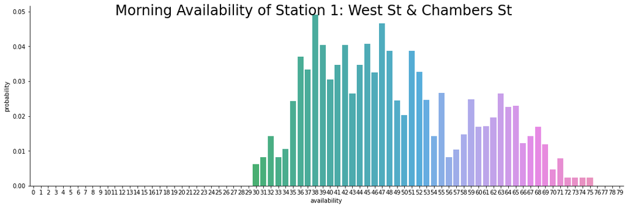

```python
#Morning
station1_morning = pd.DataFrame({ "probability":\
                         list(stationary_dist_west_st_chambers_morning),"availability":[i for i in range(len(stationary_dist_west_st_chambers_morning))], "type":\
                         ["morning"]*len(stationary_dist_west_st_chambers_morning)})

plt = sns.catplot(data =station1_morning , x = "availability", y = "probability", kind="bar", aspect = 3)
plt.fig.suptitle("Morning Availability of Station 1: West St & Chambers St",fontsize=24, fontdict={"weight": "bold"});
```

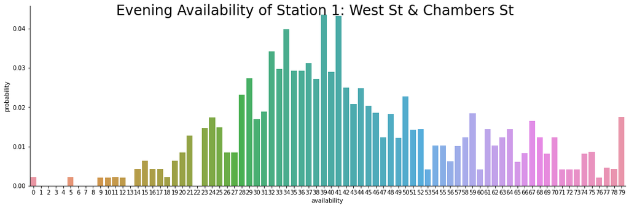

```python
#Evening
station1_evening = pd.DataFrame({ "probability":\
                         list(stationary_dist_west_st_chambers_evening),"availability":[i for i in range(len(stationary_dist_west_st_chambers_evening))], "type":\
                         ["evening"]*len(stationary_dist_west_st_chambers_evening)})

plt = sns.catplot(data =station1_evening , x = "availability", y = "probability", kind="bar", aspect = 3)
plt.fig.suptitle("Evening Availability of Station 1: West St & Chambers St",fontsize=24, fontdict={"weight": "bold"});
```

### Station 2: W 21 St & 6 Ave

From the Morning plot of Station 2, we can see that having 72 bikes has the largest probability of around 4%, which means that there is a possibility that the number of bikes in the station reaches the capacity. Also, there is always available bikes at the station. The probability of having 20 to 50 bikes at the station is more than 50%, as calculated below.

From the Evening plot of Station 2, we notice that the probability of having zero bikes at the station is high (~3.5%). Moreover, the probability of having 72 bikes at the station is the largest (more than ~4%). This implies that this station might have capacity issues since its most likely to either have no available bikes or to have 72 bikes available. The probability of having different number of bikes is evenly spread.

Based on the above observations and the plots below, it appears that the number of available bikes at this CitiBike station with the largest probability is 72, which is the maximum capacity. This suggests that it would be beneficial to add more docks.

```python
#Probability of having 20-50 bikes available at the station
(stationary_dist_west21_morning)[20:53].sum()
```

```
(0.5566996170640442+0j)
```

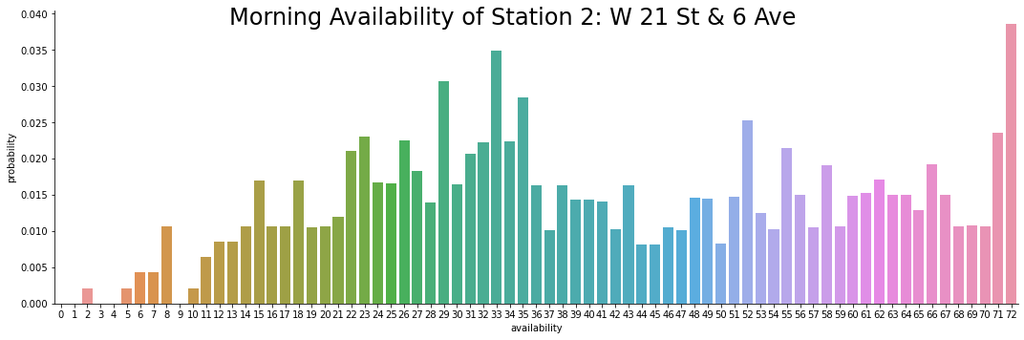

```python
#Morning
station2_morning = pd.DataFrame({ "probability":\
                         list(stationary_dist_west21_morning),"availability":[i for i in range(len(stationary_dist_west21_morning))], "type":\
                         ["morning"]*len(stationary_dist_west21_morning)})

plt = sns.catplot(data =station2_morning , x = "availability", y = "probability", kind="bar", aspect = 3)
plt.fig.suptitle("Morning Availability of Station 2: W 21 St & 6 Ave",fontsize=24, fontdict={"weight": "bold"});
```

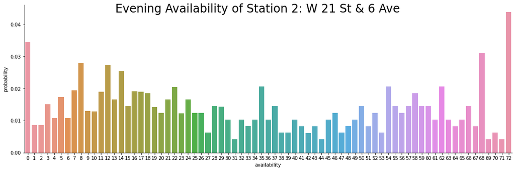

```python
#Evening
station2_evening = pd.DataFrame({ "probability":\
                         list(stationary_dist_west21_evening),"availability":[i for i in range(len(stationary_dist_west21_evening))], "type":\
                         ["evening"]*len(stationary_dist_west21_evening)})

plt = sns.catplot(data =station2_evening , x = "availability", y = "probability", kind="bar", aspect = 3)
plt.fig.suptitle("Evening Availability of Station 2: W 21 St & 6 Ave",fontsize=24, fontdict={"weight": "bold"});
```

### Station 3: Broadway & E 21 St

From the Morning plot of Station 3, we observe that there is a ~25% chance that the number of availbale bikes will be between 28 and 35 and ~40% chance that the number of available bikes will be between 49 and 60, as shown below. The largest number of availabel bikes with the highest probability of ~5% is 57.

From the Evening plot of Station 3, we notice that there is a possibility that there will be zero bikes at the station (around 2.5%). Moreover, the probability of having 60 bikes at the station is the largest (~5%). This implies that this station might have capacity issues since its most likely to either have no available bikes or to have 60 bikes available. The probability of having different number of bikes is evenly spread.

Based on the above observations and the plots below, it appears that it might be worth considering moving some bikes in the morning from this CitiBike station to a different station to better utilize the bikes and meet demand.

```python
#Probability of having 49-60 bikes available at the station
(stationary_dist_broadway_morning)[49:61].sum()
```

```
(0.3740023360072261+0j)
```

```python
#Probability of having 28-35 bikes available at the station
(stationary_dist_broadway_morning)[28:36].sum()
```

```
(0.25839171626214463+0j)
```

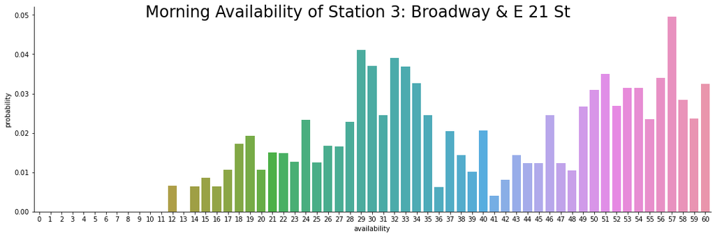

```python
#Morning
station3_morning = pd.DataFrame({ "probability":\
                         list(stationary_dist_broadway_morning),"availability":[i for i in range(len(stationary_dist_broadway_morning))], "type":\
                         ["morning"]*len(stationary_dist_broadway_morning)})

plt = sns.catplot(data =station3_morning , x = "availability", y = "probability", kind="bar", aspect = 3)
plt.fig.suptitle("Morning Availability of Station 3: Broadway & E 21 St",fontsize=24, fontdict={"weight": "bold"});
```

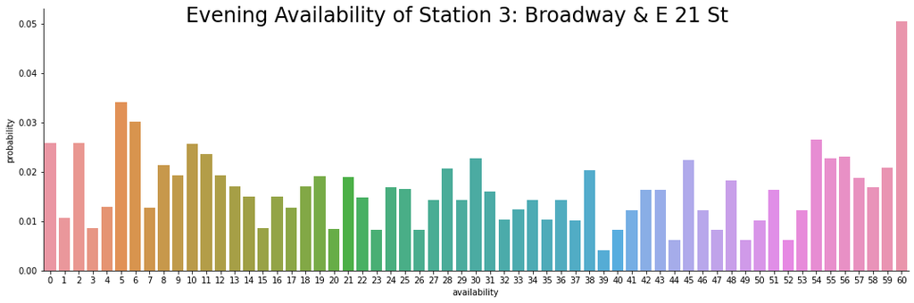

```python
#Evening
station3_evening = pd.DataFrame({ "probability":\
                         list(stationary_dist_broadway_evening),"availability":[i for i in range(len(stationary_dist_broadway_evening))], "type":\
                         ["evening"]*len(stationary_dist_broadway_evening)})

plt = sns.catplot(data =station3_evening , x = "availability", y = "probability", kind="bar", aspect = 3)
plt.fig.suptitle("Evening Availability of Station 3: Broadway & E 21 St",fontsize=24, fontdict={"weight": "bold"});
```

# Report Notes

After running the analysis and studying the results, it is worth mentioning that the team expected to see graphs with positive and negative exponential stationary distributions; if the morning stationary distribution was positive, the evening would have been negative, and vice versa.

The reason behind the deviation of results from the expectations of the team was potentially due to the following reasons:

1. The method used to estimate the number of available bikes at the initial state of the Markov Chain.
2. The defined morning and evening timeframes.